# Model Experiments

## 14.7 Where the specifications disagree most

```r
shifts <- va_complete %>%
  mutate(
    rank_shift_M2_vs_M1 = rank_M1 - rank_M2,    # positive = M2 ranks them better
    rank_shift_M0_vs_M1 = rank_M1 - rank_M0
  ) %>%
  arrange(desc(abs(rank_shift_M2_vs_M1)))

cat("Top 15 schools where M2 (expected absence) ranks the school higher than M1:\n")
```

```
Top 15 schools where M2 (expected absence) ranks the school higher than M1:
```

```r
shifts %>%
  filter(rank_shift_M2_vs_M1 > 0) %>%
  slice_head(n = 15) %>%
  select(SCHNAME, LANAME, rank_M1, rank_M2,
         rank_shift_M2_vs_M1, vadd_M1, vadd_M2) %>%
  knitr::kable(digits = 2)
```

| SCHNAME | LANAME | rank_M1 | rank_M2 | rank_shift_M2_vs_M1 | vadd_M1 | vadd_M2 |
| --- | --- | --- | --- | --- | --- | --- |
| Ashcroft Technology Academy | Wandsworth | 3322 | 233 | 3089 | -4.99 | 5.45 |
| Eden Boys’ School, Birmingham | Birmingham | 3082 | 68 | 3014 | -3.03 | 8.51 |
| Beths Grammar School | Bexley | 3037 | 183 | 2854 | -2.88 | 5.98 |
| Tauheedul Islam Boys’ High School | Blackburn with Darwen | 2651 | 94 | 2557 | -1.79 | 7.63 |
| Winton Academy | Bournemouth, Christchurch and Poole | 2740 | 441 | 2299 | -2.00 | 3.89 |
| King Edward VI Five Ways School | Birmingham | 2647 | 364 | 2283 | -1.78 | 4.34 |
| Thomas Telford University Technical College | Wolverhampton | 2856 | 576 | 2280 | -2.31 | 3.18 |
| Abbey Grange Church of England Academy | Leeds | 2713 | 521 | 2192 | -1.92 | 3.44 |
| St Aloysius RC College | Islington | 2338 | 188 | 2150 | -1.11 | 5.87 |
| Our Lady’s RC High School | Manchester | 2889 | 854 | 2035 | -2.39 | 2.10 |
| Torquay Boys’ Grammar School | Torbay | 2540 | 508 | 2032 | -1.52 | 3.50 |
| Norton Hill Academy | Bath and North East Somerset | 2946 | 980 | 1966 | -2.55 | 1.71 |
| Stepney All Saints Church of England Secondary School | Tower Hamlets | 2871 | 908 | 1963 | -2.34 | 1.93 |
| E-ACT Heartlands Academy | Birmingham | 3080 | 1145 | 1935 | -3.03 | 1.32 |
| Upton-by-Chester High School | Cheshire West and Chester | 2657 | 736 | 1921 | -1.80 | 2.53 |

```r
cat("\nTop 15 schools where M2 (expected absence) ranks the school *lower* than M1:\n")
```

```
Top 15 schools where M2 (expected absence) ranks the school *lower* than M1:
```

```r
shifts %>%
  filter(rank_shift_M2_vs_M1 < 0) %>%
  arrange(rank_shift_M2_vs_M1) %>%
  slice_head(n = 15) %>%
  select(SCHNAME, LANAME, rank_M1, rank_M2,
         rank_shift_M2_vs_M1, vadd_M1, vadd_M2) %>%
  knitr::kable(digits = 2)
```

| SCHNAME | LANAME | rank_M1 | rank_M2 | rank_shift_M2_vs_M1 | vadd_M1 | vadd_M2 |
| --- | --- | --- | --- | --- | --- | --- |
| The Sacred Heart Language College | Harrow | 473 | 2979 | -2506 | 3.12 | -3.06 |
| The King David High School | Manchester | 201 | 2267 | -2066 | 4.79 | -1.16 |
| Scott Medical and Healthcare College | Plymouth | 365 | 2418 | -2053 | 3.60 | -1.48 |
| Wapping High School | Tower Hamlets | 533 | 2538 | -2005 | 2.90 | -1.78 |
| Kendrick School | Reading | 1257 | 3197 | -1940 | 0.88 | -4.18 |
| Bushey Meads School | Hertfordshire | 845 | 2724 | -1879 | 1.85 | -2.27 |
| Prendergast School | Lewisham | 245 | 2117 | -1872 | 4.40 | -0.81 |
| St George’s School | Hertfordshire | 1070 | 2885 | -1815 | 1.33 | -2.69 |
| Herschel Grammar School | Slough | 973 | 2750 | -1777 | 1.54 | -2.35 |
| Watford Grammar School for Girls | Hertfordshire | 1107 | 2861 | -1754 | 1.24 | -2.62 |
| Islip Manor High School | Ealing | 1353 | 3078 | -1725 | 0.71 | -3.52 |
| Dixons Brooklands Academy | Manchester | 840 | 2562 | -1722 | 1.86 | -1.83 |
| Wolverhampton Girls’ High School | Wolverhampton | 1020 | 2594 | -1574 | 1.42 | -1.92 |
| Outwood Academy Portland | Nottinghamshire | 719 | 2276 | -1557 | 2.26 | -1.17 |
| Blackfen School for Girls | Bexley | 1437 | 2990 | -1553 | 0.54 | -3.11 |

The pattern that should emerge: **schools that work hard to lift attendance** (low residual absence given their intake) rank higher under M2 than under M1, because M2 returns the credit for that work to the school’s residual. **Schools coasting on a low-absence intake** see no such uplift — their attendance is already explained by who walks through the door.

## 14.8 Brighton & Hove: school-by-school under all three specifications

```r
bh_va <- va_complete %>%
  filter(grepl("Brighton", LANAME)) %>%
  arrange(desc(vadd_M1))

# Pull each school's residual absence (school mean, log-scale, then converted to %-pts)
bh_resid_abs <- stage2_data %>%
  filter(grepl("Brighton", LANAME)) %>%
  group_by(URN, SCHNAME) %>%
  summarise(
    mean_obs_abs       = mean(PERCTOT, na.rm = TRUE),
    mean_expected_abs  = mean(expected_absence, na.rm = TRUE),
    mean_resid_abs_log = mean(residual_absence_log, na.rm = TRUE),
    .groups = "drop"
  ) %>%
  mutate(resid_abs_pp = mean_obs_abs - mean_expected_abs)

bh_combined <- bh_va %>%
  left_join(bh_resid_abs, by = c("URN", "SCHNAME")) %>%
  select(SCHNAME,
         vadd_M0, vadd_M1, vadd_M2,
         mean_obs_abs, mean_expected_abs, resid_abs_pp)

knitr::kable(bh_combined, digits = 2,
             caption = "Brighton & Hove schools: value-added (ATT8 points) under each specification, plus the residual-absence indicator")
```

Brighton & Hove schools: value-added (ATT8 points) under each specification, plus the residual-absence indicator

| SCHNAME | vadd_M0 | vadd_M1 | vadd_M2 | mean_obs_abs | mean_expected_abs | resid_abs_pp |
| --- | --- | --- | --- | --- | --- | --- |
| Dorothy Stringer School | 2.75 | 3.35 | 3.32 | 10.09 | 9.58 | 0.52 |
| Varndean School | 3.15 | 2.91 | 3.73 | 9.16 | 9.67 | -0.51 |
| King’s School | 4.83 | 2.26 | 5.45 | 6.64 | 8.96 | -2.32 |
| Brighton Aldridge Community Academy | 0.25 | 1.41 | 0.65 | 15.79 | 12.94 | 2.85 |
| Portslade Aldridge Community Academy | 0.42 | 1.32 | 0.90 | 11.66 | 10.97 | 0.69 |
| Hove Park School and Sixth Form Centre | -0.27 | 1.06 | 0.20 | 11.79 | 10.55 | 1.25 |
| Blatchington Mill School | -0.65 | 0.48 | -0.15 | 10.15 | 9.05 | 1.10 |
| Cardinal Newman Catholic School | 1.03 | -0.31 | 1.57 | 9.00 | 8.84 | 0.16 |
| Longhill High School | -2.97 | -1.55 | -2.62 | 14.69 | 11.85 | 2.84 |
| Patcham High School | -2.66 | -3.06 | -2.20 | 8.76 | 9.73 | -0.97 |

The `resid_abs_pp` column is the **school-controllable absence indicator** described in the motivation: positive values mean the school has more absence than the stage-1 model would expect from its intake; negative values mean the school is doing better on attendance than its intake would predict.

The combination of **`vadd_M2` plus `resid_abs_pp`** is the transparent two-component view: how much the school adds to attainment (with attendance management already credited), and *separately* how much of that comes through unusually good (or bad) attendance management.

## 14.9 Sensitivity: bootstrap stability of B&H rankings

We resample LAs-with-replacement (clustered bootstrap, since school-years within an LA are not independent) and refit stages 1 and 2. For each replicate we record each B&H school’s value-added rank under M1 and M2.

**NoteHow the bootstrap works, in lay terms**

A single value-added number for a school is just a point estimate — it’s the answer that comes out *if the data we have is exactly the right sample to learn from*. In practice, England’s ~3,000 secondaries are themselves a kind of sample of “schools that could exist”, and the LAs they sit in are not independent of each other (schools in the same LA share intake, funding, policy and management context). The model’s standard errors handle some of that, but not all of it. The bootstrap gives us a more honest picture of how much a school’s ranking could move just because of who else is in the comparison set.

The procedure is essentially: **pretend the data we have is the population, then draw lots of “alternative Englands” from it and see how stable each school’s answer is across them.**

Concretely, one replicate looks like this:

1. **Resample LAs.** Take the list of England’s local authorities and draw from it 152 times *with replacement* — so some LAs end up in the new sample twice or three times, and others not at all. This is the “clustered” part: we resample whole LAs rather than individual schools, because schools within the same LA are not independent observations.
2. **Build a synthetic England.** For each LA picked, pull in all that LA’s school-years as they appear in the real data. The result is a synthetic dataset of similar size to the original, but with a slightly different mix of LAs — some over-represented, some absent.
3. **Re-run the whole pipeline.** Refit stage 1 (expected absence) and the two stage-2 attainment models (M1 and M2) on the synthetic dataset.
4. **Record each B&H school’s rank.** For every Brighton and Hove school that appears in the synthetic dataset, log its value-added rank under M1 and under M2.
5. **Repeat n times** (here `n = 50` — bumped up to a few hundred or a thousand for production reporting).

After all replicates, each school has a *distribution* of ranks rather than a single rank. The **5th–95th percentile interval** of that distribution is a 90% bootstrap interval: a school whose interval runs from rank 800 to rank 850 is *robustly* placed; a school whose interval runs from rank 400 to rank 1,800 is in a position the data cannot pin down precisely.

Why this matters: a single point-estimate rank looks much more authoritative than the underlying data warrants. Reporting the interval alongside the point estimate is honest practice and helps regulators, parents and school leaders avoid over-interpreting small year-on-year or specification-driven movements.

A few practical caveats specific to this setup:

- **Resampling LAs (not schools)** preserves the within-LA correlation structure. Resampling individual school-years would make the intervals look artificially tight.
- **Why with replacement?** This is what makes each replicate a “different draw” from the same underlying population. Without replacement we’d just get back the original sample every time.
- **Stage 1 is refit each replicate.** Expected absence is recomputed inside each synthetic England, so the uncertainty in the *first* stage is propagated into the second — this addresses the generated-regressor problem mentioned in the caveats below.
- **Bootstrap size matters.** With only 50 replicates, the 5th–95th interval is itself estimated noisily. The structure is sound but the intervals are wider than a 1,000-replicate run would give. Treat the table below as illustrative of the *method* rather than the final word on each school’s interval.

```r
set.seed(42)
n_boot <- 50  # keep small to bound render time; bump for production use

la_pool <- unique(stage2_data$LANAME)

boot_rank <- function() {
  # Sample LAs with replacement
  la_sample <- sample(la_pool, length(la_pool), replace = TRUE)
  d_boot <- map_dfr(seq_along(la_sample), function(i) {
    stage2_data %>% filter(LANAME == la_sample[i]) %>% mutate(.boot_la = i)
  })
  if (nrow(d_boot) < 1000) return(NULL)

  # Refit stage 1 on the bootstrap sample
  s1_b <- try(lmer(
    log(PERCTOT) ~ log(PTFSM6CLA1A) + log(PNUMEAL) + ks2_c +
      gorard_segregation +
      (1 | year_label) + (1 | gor_name),
    data = d_boot, REML = TRUE,
    control = lmerControl(optimizer = "bobyqa", optCtrl = list(maxfun = 20000))
  ), silent = TRUE)
  if (inherits(s1_b, "try-error")) return(NULL)

  d_boot$log_expected_absence <- predict(s1_b, newdata = d_boot,
                                          re.form = NULL,
                                          allow.new.levels = TRUE)

  # Refit M1 and M2
  m1_b <- try(lmer(
    log(ATT8SCR) ~ log(PTFSM6CLA1A) + log(PERCTOT) + log(PNUMEAL) +
      ks2_c + ADMPOL_PT + gorard_segregation +
      remained_in_the_same_school +
      teachers_on_leadership_pay_range_percent +
      log(average_number_of_days_taken) +
      (1 | year_label) + (1 | gor_name),
    data = d_boot, REML = TRUE,
    control = lmerControl(optimizer = "bobyqa", optCtrl = list(maxfun = 20000))
  ), silent = TRUE)

  m2_b <- try(lmer(
    log(ATT8SCR) ~ log(PTFSM6CLA1A) + log_expected_absence + log(PNUMEAL) +
      ks2_c + ADMPOL_PT + gorard_segregation +
      (1 | year_label) + (1 | gor_name),
    data = d_boot, REML = TRUE,
    control = lmerControl(optimizer = "bobyqa", optCtrl = list(maxfun = 20000))
  ), silent = TRUE)

  if (inherits(m1_b, "try-error") || inherits(m2_b, "try-error")) return(NULL)

  d_boot$resid_M1 <- residuals(m1_b)
  d_boot$resid_M2 <- residuals(m2_b)

  d_boot %>%
    group_by(URN, SCHNAME, LANAME) %>%
    summarise(va_M1 = mean(resid_M1), va_M2 = mean(resid_M2), .groups = "drop") %>%
    mutate(rank_M1 = rank(-va_M1), rank_M2 = rank(-va_M2))
}

boot_results <- map_dfr(1:n_boot, function(i) {
  res <- boot_rank()
  if (!is.null(res)) res$rep <- i
  res
})

cat("Successful bootstrap replicates:", length(unique(boot_results$rep)), "/", n_boot, "\n")
```

```
Successful bootstrap replicates: 50 / 50
```

```r
bh_boot <- boot_results %>%
  filter(grepl("Brighton", LANAME)) %>%
  group_by(SCHNAME) %>%
  summarise(
    rank_M1_median = median(rank_M1),
    rank_M1_q05    = quantile(rank_M1, 0.05),
    rank_M1_q95    = quantile(rank_M1, 0.95),
    rank_M2_median = median(rank_M2),
    rank_M2_q05    = quantile(rank_M2, 0.05),
    rank_M2_q95    = quantile(rank_M2, 0.95),
    .groups = "drop"
  ) %>%
  arrange(rank_M2_median)

knitr::kable(bh_boot, digits = 0,
             caption = "Brighton & Hove school rank uncertainty under M1 and M2 (clustered bootstrap, n_boot replicates above)")
```

Brighton & Hove school rank uncertainty under M1 and M2 (clustered bootstrap, n_boot replicates above)

| SCHNAME | rank_M1_median | rank_M1_q05 | rank_M1_q95 | rank_M2_median | rank_M2_q05 | rank_M2_q95 |
| --- | --- | --- | --- | --- | --- | --- |
| King’s School | 243 | 152 | 320 | 221 | 155 | 285 |
| Varndean School | 127 | 82 | 176 | 308 | 250 | 427 |
| Dorothy Stringer School | 93 | 55 | 136 | 341 | 279 | 455 |
| Portslade Aldridge Community Academy | 182 | 129 | 265 | 561 | 483 | 756 |
| Cardinal Newman Catholic School | 681 | 477 | 896 | 706 | 530 | 913 |
| Hove Park School and Sixth Form Centre | 239 | 166 | 337 | 829 | 672 | 1054 |
| Blatchington Mill School | 376 | 275 | 539 | 1028 | 823 | 1261 |
| Brighton Aldridge Community Academy | 314 | 232 | 448 | 1265 | 1117 | 1509 |
| Patcham High School | 1268 | 1109 | 1516 | 1397 | 1300 | 1639 |
| Longhill High School | 1110 | 981 | 1357 | 1845 | 1704 | 2052 |

The width of the 5–95% interval gives an honest sense of how much each school’s position can move purely through sampling. Schools whose interval brackets stay tight under both M1 and M2 are *robustly* ranked; wide intervals signal cases where the methodological choice or a small change in sample matters.

## 14.10 Take-aways

**TipWhat this experiment tells us**

1. **Most rankings are likely robust to the absence specification.** If M1 and M2 produce a Spearman rank correlation above ~0.9, then for parental-choice purposes the simpler Analysis E specification is fine.
2. **Where they disagree, the disagreement is informative.** A school whose M2 rank is materially better than its M1 rank is plausibly *managing attendance unusually well* given its intake; the reverse pattern flags a school whose M1 advantage rests on an attendance profile its intake would have predicted anyway.
3. **The combined indicator (value-added + residual absence) is the most transparent reporting unit.** It separates “this school adds points to attainment” from “this school’s pupils attend more than their intake predicts” — two distinct signals that the single-residual M1 reporting fuses together.
4. **Stage 1 is the binding constraint.** With only FSM, EAL, low prior attainment and segregation as fixed exogenous predictors, stage 1’s discriminating power leans heavily on the LA random effect. Adding richer area-level controls (IDACI, area health indicators, SEN/EHCP rates, neighbourhood deprivation deciles) would sharpen the decomposition substantially.
5. **Bootstrap confidence intervals are wide for many schools.** A single point estimate of value-added is almost always more precise than the underlying data warrants. Reporting the interval alongside the point estimate is honest practice.

**WarningWhat this experiment does not do**

- **It does not establish causality.** All three specifications are observational. The two-stage approach reduces one specific bias (over-attributing exogenous absence to school behaviour) but does not eliminate omitted-variable bias from unmeasured intake characteristics.
- **It does not address measurement error in stage 1.** Expected absence enters stage 2 as if it were known with certainty. Properly accounting for the generated-regressor problem requires either a full bootstrap of standard errors (the small simulation above is a start) or an instrumental-variable / structural-equation framing.
- **It does not test pupil-level decompositions.** Pupil-level NPD data with linked attendance, intake and outcomes would allow a much sharper version of this analysis, including who within each school benefits from attendance management.

## 14.11 Direct test: expected vs residual absence in the same model

The M1↔︎M2 FSM equality is partly mechanical (stage 1 residuals are orthogonal to stage 1 regressors by construction), so the cleanest test of whether the school-controllable absence component matters at population level is to put **both components into the same attainment model** and read off their coefficients side by side.

```r
mod_M_combined <- lmer(
  log(ATT8SCR) ~
    log(PTFSM6CLA1A) + log_expected_absence + residual_absence_log +
    log(PNUMEAL) + ks2_c + ADMPOL_PT + gorard_segregation +
    (1 | year_label) + (1 | OFSTEDRATING_1) + (1 | gor_name/LANAME),
  data = stage2_data,
  REML = TRUE,
  control = lmerControl(optimizer = "bobyqa", optCtrl = list(maxfun = 20000))
)

summary(mod_M_combined)
```

```
Linear mixed model fit by REML. t-tests use Satterthwaite's method [
lmerModLmerTest]
Formula:
log(ATT8SCR) ~ log(PTFSM6CLA1A) + log_expected_absence + residual_absence_log +
    log(PNUMEAL) + ks2_c + ADMPOL_PT + gorard_segregation + (1 |
    year_label) + (1 | OFSTEDRATING_1) + (1 | gor_name/LANAME)
   Data: stage2_data
Control: lmerControl(optimizer = "bobyqa", optCtrl = list(maxfun = 20000))

REML criterion at convergence: -23034.9

Scaled residuals:
    Min      1Q  Median      3Q     Max
-45.933  -0.439   0.044   0.501   5.475

Random effects:
 Groups          Name        Variance  Std.Dev.
 LANAME:gor_name (Intercept) 0.0007080 0.02661
 gor_name        (Intercept) 0.0001835 0.01355
 OFSTEDRATING_1  (Intercept) 0.0023517 0.04849
 year_label      (Intercept) 0.0020235 0.04498
 Residual                    0.0085705 0.09258
Number of obs: 12199, groups:
LANAME:gor_name, 152; gor_name, 9; OFSTEDRATING_1, 4; year_label, 4

Fixed effects:
                         Estimate Std. Error         df t value Pr(>|t|)
(Intercept)             4.256e+00  7.299e-02  8.287e+01  58.311  < 2e-16 ***
log(PTFSM6CLA1A)       -5.616e-02  7.648e-03  1.364e+02  -7.344 1.71e-11 ***
log_expected_absence   -2.063e-01  3.678e-02  1.217e+02  -5.609 1.30e-07 ***
residual_absence_log   -2.120e-01  4.562e-03  1.207e+04 -46.465  < 2e-16 ***
log(PNUMEAL)            8.504e-03  2.430e-03  2.247e+02   3.499 0.000563 ***
ks2_c                   3.348e-02  1.334e-03  2.264e+02  25.101  < 2e-16 ***
ADMPOL_PTOTHER NON SEL  2.778e-02  7.048e-03  1.539e+03   3.942 8.43e-05 ***
ADMPOL_PTSEL           -2.224e-02  7.229e-03  1.172e+04  -3.077 0.002094 **
gorard_segregation      1.702e-02  4.852e-02  4.381e+02   0.351 0.725894
---
Signif. codes:  0 '***' 0.001 '**' 0.01 '*' 0.05 '.' 0.1 ' ' 1

Correlation of Fixed Effects:
            (Intr) l(PTFS lg_xp_ rsdl__ l(PNUM ks2_c  ADMPNS ADMPOL
l(PTFSM6CLA  0.763
lg_xpctd_bs -0.863 -0.940
rsdl_bsnc_l -0.001  0.023 -0.009
lg(PNUMEAL) -0.771 -0.863  0.883 -0.024
ks2_c       -0.811 -0.728  0.878 -0.017  0.795
ADMPOL_PTNS -0.060  0.076 -0.071  0.027 -0.059 -0.049
ADMPOL_PTSE -0.008  0.016 -0.021 -0.014 -0.111 -0.266  0.471
grrd_sgrgtn  0.207  0.388 -0.386  0.020 -0.332 -0.317  0.283  0.085
```

```r
# Pull the absence-related coefficients into a single table
absence_coef_table <- bind_rows(
  extract_fixef_table(mod_M1, "M1: raw absence")          %>%
    filter(term == "log(PERCTOT)") %>% mutate(component = "raw absence"),
  extract_fixef_table(mod_M2, "M2: expected absence")     %>%
    filter(term == "log_expected_absence") %>% mutate(component = "expected absence"),
  extract_fixef_table(mod_M_combined, "M_combined: both") %>%
    filter(term %in% c("log_expected_absence", "residual_absence_log")) %>%
    mutate(component = ifelse(term == "log_expected_absence",
                               "expected absence", "residual absence"))
) %>%
  select(model, component, estimate, std_error, p_value)

knitr::kable(absence_coef_table, digits = 4,
             caption = "Absence-coefficient comparison across M1, M2 and the combined model. The M_combined row for residual absence is the direct test of whether school-controllable absence carries marginal predictive power.")
```

Absence-coefficient comparison across M1, M2 and the combined model. The M_combined row for residual absence is the direct test of whether school-controllable absence carries marginal predictive power.

| model | component | estimate | std_error | p_value |
| --- | --- | --- | --- | --- |
| M1: raw absence | raw absence | -0.2073 | 0.0045 | 0 |
| M2: expected absence | expected absence | -0.2220 | 0.0354 | 0 |
| M_combined: both | expected absence | -0.2063 | 0.0368 | 0 |
| M_combined: both | residual absence | -0.2120 | 0.0046 | 0 |

```r
cat("Model fit comparison:\n")
```

```
Model fit comparison:
```

```r
fit_combined <- tibble(
  model         = c("M1", "M2", "M_combined"),
  n_obs         = c(nobs(mod_M1), nobs(mod_M2), nobs(mod_M_combined)),
  R2_marginal   = c(as.numeric(performance::r2(mod_M1)$R2_marginal),
                     as.numeric(performance::r2(mod_M2)$R2_marginal),
                     as.numeric(performance::r2(mod_M_combined)$R2_marginal)),
  R2_conditional = c(as.numeric(performance::r2(mod_M1)$R2_conditional),
                      as.numeric(performance::r2(mod_M2)$R2_conditional),
                      as.numeric(performance::r2(mod_M_combined)$R2_conditional)),
  AIC           = c(AIC(mod_M1), AIC(mod_M2), AIC(mod_M_combined))
)
knitr::kable(fit_combined, digits = 4,
             caption = "Fit statistics: M_combined vs M1 vs M2")
```

Fit statistics: M_combined vs M1 vs M2

| model | n_obs | R2_marginal | R2_conditional | AIC |
| --- | --- | --- | --- | --- |
| M1 | 12199 | 0.6512 | 0.7793 | -23135.16 |
| M2 | 12199 | 0.5312 | 0.7486 | -21034.33 |
| M_combined | 12199 | 0.6404 | 0.7773 | -23006.91 |

**NoteHow to read the combined-model output**

- **If the residual-absence coefficient is small relative to the expected-absence coefficient** (and/or non-significant), the school-controllable component of absence carries little marginal predictive power for attainment at the population level after intake is accounted for. Read this as: at national average, the bulk of the absence → attainment association runs through structural/intake factors that schools don’t directly control.
- **If the two coefficients are similar in magnitude**, both components matter independently — intake-driven absence and school-management absence have comparable per-percentage-point effects on attainment.
- **If residual absence has a larger coefficient than expected absence**, then conditional on intake, what schools *do* about attendance matters more than the intake-driven baseline. This would be a strong finding for actionable policy.

Note that the residual-absence coefficient here is the **partial** effect: the marginal contribution of school-controllable absence after intake-driven absence is already in the model. It is not the same as the unconditional correlation between residual absence and attainment.

```r
s_comb <- summary(mod_M_combined)$coefficients
beta_exp  <- s_comb["log_expected_absence",  "Estimate"]
se_exp    <- s_comb["log_expected_absence",  "Std. Error"]
p_exp     <- s_comb["log_expected_absence",  "Pr(>|t|)"]
beta_res  <- s_comb["residual_absence_log",  "Estimate"]
se_res    <- s_comb["residual_absence_log",  "Std. Error"]
p_res     <- s_comb["residual_absence_log",  "Pr(>|t|)"]

s_M1 <- summary(mod_M1)$coefficients
beta_M1_abs <- s_M1["log(PERCTOT)", "Estimate"]

ratio <- abs(beta_res) / abs(beta_exp)

stars <- function(p) {
  if (is.na(p)) return("")
  if (p < 0.001) return("\\*\\*\\*")
  if (p < 0.01)  return("\\*\\*")
  if (p < 0.05)  return("\\*")
  return(" (n.s.)")
}

cat("::: {.callout-tip}\n")
```

**Tip**

```r
cat("## What the combined model is actually saying here\n\n")
```

## 14.12 What the combined model is actually saying here

```r
cat(sprintf(
  "In our fit, the coefficient on **expected absence** is %.3f%s (SE %.3f) and the coefficient on **residual absence** is %.3f%s (SE %.3f). For comparison, M1's single coefficient on raw absence sits at %.3f --- effectively a weighted average of the two components.\n\n",
  beta_exp, stars(p_exp), se_exp,
  beta_res, stars(p_res), se_res,
  beta_M1_abs))
```

In our fit, the coefficient on **expected absence** is -0.206*** (SE 0.037) and the coefficient on **residual absence** is -0.212*** (SE 0.005). For comparison, M1’s single coefficient on raw absence sits at -0.207 — effectively a weighted average of the two components.

```r
if (ratio < 0.5) {
  cat(sprintf(
    "The residual-absence coefficient is materially **smaller** than the expected-absence coefficient (about %.0f%% of its magnitude). Practically, this means a one-percentage-point movement in the *intake-predicted* component of absence is associated with roughly %.1f times the attainment shift that the same movement in the *school-controllable* component is associated with. ",
    100 * ratio, 1 / ratio))
  if (p_res > 0.05) {
    cat("And the residual-absence coefficient is not statistically significant in this model, so we cannot rule out that the school-controllable component has *no* marginal effect on attainment at population level once intake-driven absence is held constant.\n\n")
  } else {
    cat("Despite the gap, the residual-absence coefficient is statistically distinguishable from zero --- school-controllable absence does carry signal, just less per percentage point than the intake-driven component.\n\n")
  }
  cat("Interpreted in the framing we set out at the start: at national level the absence → attainment story is mostly *structural*. The bit of school-level absence that schools could plausibly act on (residual absence) shifts attainment less, percentage point for percentage point, than the bit baked in by intake. This is consistent with two non-exclusive readings:\n\n")
  cat("1. **Mechanically**, the variation in residual absence is small enough that even modest measurement noise dilutes its signal in the model. Stage 1 explains a meaningful share of school-level absence variance; what remains is partly noise and partly the school-controllable component, and the model cannot fully separate them.\n")
  cat("2. **Substantively**, attainment may be more responsive to absence when absence is high *for structural reasons* (a school where absence is high because the intake brings particular needs and circumstances) than when it's high *for management reasons* (a school whose pastoral systems aren't catching the same proportion of pupils). The marginal pupil whose attendance moves in the first case may be a higher-risk pupil whose presence in school carries more attainment lift; the marginal pupil in the second case may already be relatively well-supported.\n\n")
  cat("Either way, the implication is the same: **at population level, attendance management on its own is a smaller lever than the headline raw-absence elasticity from M1 implies.** That headline number borrows force from the structural component.\n\n")
} else if (ratio < 1.5) {
  cat(sprintf("The two coefficients are roughly **comparable in magnitude** (residual at about %.0f%% of expected). Both components contribute independently to the attainment association, and the M1 raw-absence elasticity is genuinely a fair summary of both at once.\n\n", 100 * ratio))
} else {
  cat(sprintf("The residual-absence coefficient is **larger** than the expected-absence coefficient (about %.1fx). What schools do about attendance --- conditional on intake --- shifts attainment more, percentage point for percentage point, than the intake-driven baseline. This would be a strong policy finding.\n\n", ratio))
}
```

The two coefficients are roughly **comparable in magnitude** (residual at about 103% of expected). Both components contribute independently to the attainment association, and the M1 raw-absence elasticity is genuinely a fair summary of both at once.

```r
bh_resid_range <- stage2_data %>%
  filter(grepl("Brighton", LANAME)) %>%
  group_by(URN) %>%
  summarise(
    obs_abs = mean(PERCTOT, na.rm = TRUE),
    exp_abs = mean(expected_absence, na.rm = TRUE),
    .groups = "drop"
  ) %>%
  mutate(resid_pp = obs_abs - exp_abs)

cat(sprintf(
  "**The local-vs-national distinction still holds.** Even if the population-level residual-absence coefficient is small (here %.3f), individual schools can sit at very different points on the residual-absence distribution (B&H secondaries span from roughly %+.1f to %+.1f percentage points away from their intake-predicted absence). For *those* schools the relevant question is not the population-average elasticity but the actionable gap between observed and predicted attendance. The combined model tells us how to weigh the two components for *coefficient interpretation*; it doesn't tell us that residual absence is uninformative for individual school diagnostics.\n\n",
  beta_res,
  min(bh_resid_range$resid_pp, na.rm = TRUE),
  max(bh_resid_range$resid_pp, na.rm = TRUE)))
```

**The local-vs-national distinction still holds.** Even if the population-level residual-absence coefficient is small (here -0.212), individual schools can sit at very different points on the residual-absence distribution (B&H secondaries span from roughly -2.3 to +2.8 percentage points away from their intake-predicted absence). For *those* schools the relevant question is not the population-average elasticity but the actionable gap between observed and predicted attendance. The combined model tells us how to weigh the two components for *coefficient interpretation*; it doesn’t tell us that residual absence is uninformative for individual school diagnostics.

```r
cat(sprintf(
  "**Caveat on the M1 raw-absence elasticity.** With a coefficient of %.3f, M1 is implicitly weighting the structural and school-controllable components equally per percentage point. The combined model splits this into %.3f for the structural part and %.3f for the school-controllable part. If your policy question is \"how much would national-average attainment move if every school's intake-driven absence dropped by 1pp?\", the relevant coefficient is the expected-absence one (%.3f), not the raw-absence one (%.3f).\n",
  beta_M1_abs, beta_exp, beta_res, beta_exp, beta_M1_abs))
```

**Caveat on the M1 raw-absence elasticity.** With a coefficient of -0.207, M1 is implicitly weighting the structural and school-controllable components equally per percentage point. The combined model splits this into -0.206 for the structural part and -0.212 for the school-controllable part. If your policy question is “how much would national-average attainment move if every school’s intake-driven absence dropped by 1pp?”, the relevant coefficient is the expected-absence one (-0.206), not the raw-absence one (-0.207).

```r
cat(":::\n")
```

## 14.13 Brighton & Hove combined view: value-added + residual absence

The local question is sharper than the national one. Even if at the population level residual absence carries modest marginal effect, individual B&H schools can sit at very different points on the residual-absence distribution, and those differences are the actionable signal for local policy.

```r
# Re-pull B&H school-level summaries with both signals on one row
bh_local_view <- va_complete %>%
  filter(grepl("Brighton", LANAME)) %>%
  left_join(
    stage2_data %>%
      filter(grepl("Brighton", LANAME)) %>%
      group_by(URN, SCHNAME) %>%
      summarise(
        mean_obs_abs       = mean(PERCTOT, na.rm = TRUE),
        mean_expected_abs  = mean(expected_absence, na.rm = TRUE),
        n_years_obs        = n(),
        .groups = "drop"
      ) %>%
      mutate(
        resid_abs_pp = mean_obs_abs - mean_expected_abs,
        # Approximate ATT8 implication of that residual absence under the
        # M2 expected-absence elasticity (illustrative only)
        absence_implied_att8_swing = NA_real_  # placeholder; populated below
      ),
    by = c("URN", "SCHNAME")
  )

# Use the M2 expected-absence elasticity to translate residual absence into
# an indicative attainment-points equivalent, IF residual absence behaved like
# expected absence (this is illustrative — see caveat above).
beta_exp_abs <- fixef(mod_M2)["log_expected_absence"]

bh_local_view <- bh_local_view %>%
  mutate(
    # mean_att8 from earlier work; recompute robustly here
    mean_att8 = NA_real_
  )

bh_att8_means <- stage2_data %>%
  filter(grepl("Brighton", LANAME)) %>%
  group_by(URN) %>%
  summarise(mean_att8 = mean(ATT8SCR, na.rm = TRUE), .groups = "drop")

bh_local_view <- bh_local_view %>%
  select(-mean_att8) %>%
  left_join(bh_att8_means, by = "URN") %>%
  mutate(
    # log-scale change in absence implied by residual_abs_pp at school's mean
    delta_log_abs = log(mean_obs_abs) - log(mean_expected_abs),
    # Indicative ATT8 points equivalent if M2 elasticity applied
    absence_implied_att8_swing = mean_att8 *
      (exp(beta_exp_abs * delta_log_abs) - 1)
  ) %>%
  arrange(desc(vadd_M2))

bh_summary_table <- bh_local_view %>%
  select(SCHNAME,
         vadd_M1, vadd_M2,
         mean_obs_abs, mean_expected_abs, resid_abs_pp,
         absence_implied_att8_swing)

knitr::kable(bh_summary_table, digits = 2,
             caption = "Brighton & Hove combined view: model value-added (M1 vs M2) alongside residual absence (pp). The 'absence_implied_att8_swing' column gives an indicative translation of residual absence into ATT8 points under the M2 expected-absence elasticity --- illustrative only, since residual absence's true elasticity is what the combined model above estimates.")
```

Brighton & Hove combined view: model value-added (M1 vs M2) alongside residual absence (pp). The ‘absence_implied_att8_swing’ column gives an indicative translation of residual absence into ATT8 points under the M2 expected-absence elasticity — illustrative only, since residual absence’s true elasticity is what the combined model above estimates.

| SCHNAME | vadd_M1 | vadd_M2 | mean_obs_abs | mean_expected_abs | resid_abs_pp | absence_implied_att8_swing |
| --- | --- | --- | --- | --- | --- | --- |
| King’s School | 2.26 | 5.45 | 6.64 | 8.96 | -2.32 | 3.92 |
| Varndean School | 2.91 | 3.73 | 9.16 | 9.67 | -0.51 | 0.65 |
| Dorothy Stringer School | 3.35 | 3.32 | 10.09 | 9.58 | 0.52 | -0.62 |
| Cardinal Newman Catholic School | -0.31 | 1.57 | 9.00 | 8.84 | 0.16 | -0.21 |
| Portslade Aldridge Community Academy | 1.32 | 0.90 | 11.66 | 10.97 | 0.69 | -0.61 |
| Brighton Aldridge Community Academy | 1.41 | 0.65 | 15.79 | 12.94 | 2.85 | -1.59 |
| Hove Park School and Sixth Form Centre | 1.06 | 0.20 | 11.79 | 10.55 | 1.25 | -1.11 |
| Blatchington Mill School | 0.48 | -0.15 | 10.15 | 9.05 | 1.10 | -1.28 |
| Patcham High School | -3.06 | -2.20 | 8.76 | 9.73 | -0.97 | 1.13 |
| Longhill High School | -1.55 | -2.62 | 14.69 | 11.85 | 2.84 | -1.73 |

**TipReading this table for B&H**

For each school, three signals sit side by side:

1. **`vadd_M2`** — attainment value-added under the expected-absence specification (the “school does more than its intake would predict” indicator, with attendance management credited).
2. **`resid_abs_pp`** — the school-controllable absence indicator. Positive = more absence than intake predicts; negative = less.
3. **`absence_implied_att8_swing`** — the indicative ATT8 implication of that residual absence, *if* residual absence were translated through the same elasticity as expected absence. This is illustrative; the actual residual-absence elasticity is the one in the combined-model table above.

Schools where `vadd_M2` is high *and* `resid_abs_pp` is negative are doing well on attainment partly *through* unusually good attendance — a coherent management story. Schools where `vadd_M2` is high but `resid_abs_pp` is positive are adding value *despite* a worse-than-expected absence profile — pedagogically impressive, with attendance still the obvious lever to pull. Schools where `vadd_M2` is negative *and* `resid_abs_pp` is positive have attendance as the most plausible single point of intervention.

**NoteWhat `absence_implied_att8_swing` is, in lay terms**

This column is best read as a **rough translation** of “this school’s attendance is X percentage points off what its intake predicts” into “what would that be worth in Attainment 8 points if the school’s residual absence behaved like its intake-predicted absence?”. It’s a back-of-envelope conversion, useful for orientation rather than for precise prediction. Worked through step by step:

1. **Start with the gap.** `resid_abs_pp` (in percentage points) is the difference between the school’s observed absence and the absence stage 1 predicts from its intake. A school running at 11% absence with an intake-predicted 9% has a `resid_abs_pp` of +2 percentage points.
2. **Use the M2 elasticity as a yardstick.** The M2 attainment model gives us a coefficient on `log_expected_absence` — a number that says, on the log scale, how much Attainment 8 moves when (intake-predicted) absence moves by 1%. We borrow that yardstick and apply it to the *gap* between observed and predicted absence, asking: if that 2-percentage-point gap were closed (or, equivalently, if the school’s residual absence behaved the way its intake-predicted absence does), how many ATT8 points would the model expect that to be worth?
3. **Convert back to ATT8 points at the school’s level.** Multilevel models work on the log scale, so we exponentiate the change implied by the elasticity and multiply through by the school’s mean ATT8 to get the answer in raw points rather than log-scale units.

Mechanically: `absence_implied_att8_swing = mean_att8 × (exp(β × Δlog_absence) − 1)`, where `β` is the M2 elasticity and `Δlog_absence = log(observed) − log(predicted)`.

**What it does and doesn’t tell you:**

- **It does** give a usable order-of-magnitude sense of how much each school’s attendance gap “costs” or “gains” them in Attainment 8 terms, expressed in the same ATT8 units as `vadd_M2`. A swing of +1.5 means roughly “if this school’s residual absence were closed, the model implies +1.5 ATT8 points worth of attainment”.
- **It doesn’t** establish that the swing would actually be realised in practice if the school changed its attendance management. The M2 elasticity is fitted on intake-driven absence variation across England, not on the kind of variation a single school’s attendance interventions would produce. Closing residual absence might be harder than this number suggests, or it might unlock other effects this single coefficient cannot capture.
- **It is sensitive to the choice of yardstick.** We use the M2 elasticity for `log_expected_absence` because it is the most stable absence coefficient in the model. The combined-model table above estimates a *separate* elasticity for residual absence specifically; if that estimate is much smaller than the expected-absence elasticity, this column will overstate the policy-actionable swing. If it is similar, this column is a fair indicative read.
- **The sign is the most reliable part.** Treat the magnitude as illustrative, but the sign tells you which direction attendance management would push attainment for each school.

In short: this column is a translation device, not a prediction. It puts the attendance signal into the same units as the value-added signal so they can be compared at a glance, with the caveats that the conversion is approximate and the underlying causal story is what the rest of this section is trying to disentangle.

## 14.14 Worked examples: reading the joint signal across Brighton & Hove’s schools

The framing principle is simple. Under M2, `vadd_M2` measures what the school contributes to attainment over and above what its intake would predict — with attendance management already credited to the school. `resid_abs_pp` then isolates how much of that attendance management is the school’s own work as opposed to a structural feature of its intake. Reading the two side by side answers the question that a single value-added residual hides: **how much of a school’s strength or weakness comes through attendance management, and how much comes through everything else?**

```r
# Short list-formatter
list_schools <- function(shorts) {
  if (length(shorts) == 0) return(NULL)
  paste(map_chr(shorts, fmt_school), collapse = "; ")
}

cat("### Group 1 --- Adding value, with attendance management helping\n\n")
```

### 14.14.1 Group 1 — Adding value, with attendance management helping

```r
cat("These schools sit above their intake-predicted attainment *and* run lower absence than their intake would predict. The story is internally consistent: strong attainment outcomes earned at least partly through getting more pupils into class than the structural intake profile would lead you to expect.\n\n")
```

These schools sit above their intake-predicted attainment *and* run lower absence than their intake would predict. The story is internally consistent: strong attainment outcomes earned at least partly through getting more pupils into class than the structural intake profile would lead you to expect.

```r
if (length(schools_q1) > 0) {
  cat("In Brighton and Hove this group contains: ", list_schools(schools_q1), ".\n\n", sep = "")
} else {
  cat("No named B&H schools currently land in this quadrant.\n\n")
}
```

In Brighton and Hove this group contains: **Varndean** (`vadd_M2` = +3.73 pts, `resid_abs_pp` = -0.5 pp); **King’s** (`vadd_M2` = +5.45 pts, `resid_abs_pp` = -2.3 pp).

```r
cat("### Group 2 --- Adding value *despite* worse-than-predicted attendance\n\n")
```

### 14.14.2 Group 2 — Adding value *despite* worse-than-predicted attendance

```r
cat("These schools are above their intake line on attainment, but their absence is *worse* than the intake stage 1 model expects. The headline reading is pedagogically impressive: the school is delivering attainment outcomes above intake expectations even with an attendance profile that argues against it. Attendance is then the obvious next lever to pull --- if residual absence were closed, the value-added gain in `vadd_M2` would compound.\n\n")
```

These schools are above their intake line on attainment, but their absence is *worse* than the intake stage 1 model expects. The headline reading is pedagogically impressive: the school is delivering attainment outcomes above intake expectations even with an attendance profile that argues against it. Attendance is then the obvious next lever to pull — if residual absence were closed, the value-added gain in `vadd_M2` would compound.

```r
if (length(schools_q2) > 0) {
  cat("In Brighton and Hove this group contains: ", list_schools(schools_q2), ". ", sep = "")
  if ("BACA" %in% schools_q2) {
    cat("BACA is the most striking case here --- a strongly positive `vadd_M2` paired with worse-than-predicted attendance, suggesting the school is doing well by the pupils who get into class while still leaving real ground to recover on attendance management.\n\n")
  } else {
    cat("\n\n")
  }
} else {
  cat("No named B&H schools currently land in this quadrant.\n\n")
}
```

[output not shown]

```r
cat("### Group 3 --- Underperforming, with attendance as the cleanest lever\n\n")
```

### 14.14.3 Group 3 — Underperforming, with attendance as the cleanest lever

```r
cat("Both signals point the same way: attainment is below intake-predicted, and absence is worse than intake-predicted. This is the simplest local-policy reading because there is no contradiction to resolve --- attendance management is plausibly contributing to the attainment shortfall, and improving it is the most direct route to closing the value-added gap.\n\n")
```

Both signals point the same way: attainment is below intake-predicted, and absence is worse than intake-predicted. This is the simplest local-policy reading because there is no contradiction to resolve — attendance management is plausibly contributing to the attainment shortfall, and improving it is the most direct route to closing the value-added gap.

```r
if (length(schools_q3) > 0) {
  cat("In Brighton and Hove this group contains: ", list_schools(schools_q3), ".", sep = "")
  if (all(c("Longhill", "Hove Park") %in% schools_q3)) {
    cat(" Longhill and Hove Park sitting together here echoes the city's wider absence problem at the school level.")
  }
  cat("\n\n")
} else {
  cat("No named B&H schools currently land in this quadrant.\n\n")
}
```

In Brighton and Hove this group contains: **Longhill** (`vadd_M2` = -2.62 pts, `resid_abs_pp` = +2.8 pp).

```r
cat("### Group 4 --- Underperforming *despite* unusually good attendance management\n\n")
```

### 14.14.4 Group 4 — Underperforming *despite* unusually good attendance management

```r
cat("This is the hardest quadrant to read. Attainment is below intake-predicted, but absence is *better* than intake-predicted --- the school is already doing more on attendance than its intake would lead you to expect, and yet its outcomes still fall short. The implication is that the gap between observed and predicted attainment cannot be blamed on absence and must come from somewhere else: curriculum, pedagogy, leadership, cohort effects, or unmeasured intake characteristics. It is also the quadrant where the M2 specification is most diagnostic --- under the raw-absence M1 view, the school's strong attendance management would partly mask the attainment shortfall.\n\n")
```

This is the hardest quadrant to read. Attainment is below intake-predicted, but absence is *better* than intake-predicted — the school is already doing more on attendance than its intake would lead you to expect, and yet its outcomes still fall short. The implication is that the gap between observed and predicted attainment cannot be blamed on absence and must come from somewhere else: curriculum, pedagogy, leadership, cohort effects, or unmeasured intake characteristics. It is also the quadrant where the M2 specification is most diagnostic — under the raw-absence M1 view, the school’s strong attendance management would partly mask the attainment shortfall.

```r
if (length(schools_q4) > 0) {
  cat("In Brighton and Hove this group contains: ", list_schools(schools_q4), ".", sep = "")
  if ("Patcham" %in% schools_q4) {
    cat(" Patcham is the city's clearest example: it sits comfortably mid-table on raw attainment but the intake-adjusted view is less flattering, and the relatively healthy attendance figures rule out the simplest improvement story.")
  }
  cat("\n\n")
} else {
  cat("No named B&H schools currently land in this quadrant.\n\n")
}
```

In Brighton and Hove this group contains: **Patcham** (`vadd_M2` = -2.20 pts, `resid_abs_pp` = -1.0 pp). Patcham is the city’s clearest example: it sits comfortably mid-table on raw attainment but the intake-adjusted view is less flattering, and the relatively healthy attendance figures rule out the simplest improvement story.

```r
if (length(schools_q5) > 0) {
  cat("### Group 5 --- Close to intake expectations on at least one axis\n\n")
  cat("These schools sit close to zero on either value-added or residual absence (or both), so the joint reading is less directional. They are doing roughly what their intake predicts on at least one of the two signals.\n\n")
  cat("In Brighton and Hove this group contains: ", list_schools(schools_q5), ".\n\n", sep = "")
}
```

### 14.14.5 Group 5 — Close to intake expectations on at least one axis

These schools sit close to zero on either value-added or residual absence (or both), so the joint reading is less directional. They are doing roughly what their intake predicts on at least one of the two signals.

In Brighton and Hove this group contains: **Cardinal Newman** (`vadd_M2` = +1.57 pts, `resid_abs_pp` = +0.2 pp); **Blatchington Mill** (`vadd_M2` = -0.15 pts, `resid_abs_pp` = +1.1 pp); **Hove Park** (`vadd_M2` = +0.20 pts, `resid_abs_pp` = +1.2 pp).

```r
# Pairwise commentary
cat("### Two paired readings worth noting explicitly\n\n")
```

### 14.14.6 Two paired readings worth noting explicitly

```r
varndean_row <- bh_named %>% filter(short == "Varndean")
kings_row    <- bh_named %>% filter(short == "King's")
if (nrow(varndean_row) == 1 && nrow(kings_row) == 1) {
  if (varndean_row$quadrant == kings_row$quadrant) {
    cat("**Varndean and King's** are often twinned in city debate, and on this combined view they land in the same quadrant (", varndean_row$quadrant, "), so the popular pairing is empirically reasonable: similar attainment story, similar attendance story.\n\n", sep = "")
  } else {
    cat("**Varndean and King's** are often twinned in city debate, but on this combined view they land in different quadrants --- ", fmt_school("Varndean"), " sits in *", varndean_row$quadrant, "*, while ", fmt_school("King's"), " sits in *", kings_row$quadrant, "*. The popular twinning papers over a real difference in either attainment story or attendance management.\n\n", sep = "")
  }
}
```

**Varndean and King’s** are often twinned in city debate, and on this combined view they land in the same quadrant (Q1: value-added with attendance helping), so the popular pairing is empirically reasonable: similar attainment story, similar attendance story.

```r
longhill_row <- bh_named %>% filter(short == "Longhill")
hovepark_row <- bh_named %>% filter(short == "Hove Park")
if (nrow(longhill_row) == 1 && nrow(hovepark_row) == 1) {
  if (longhill_row$quadrant == hovepark_row$quadrant) {
    cat("**Longhill and Hove Park** are similarly often discussed together as the city's high-absence schools. They land in the same quadrant here (", longhill_row$quadrant, "), so the joint reading reinforces rather than complicates the conventional pairing.\n\n", sep = "")
  } else {
    cat("**Longhill and Hove Park** both have high observed absence, but the joint reading splits them: ", fmt_school("Longhill"), " sits in *", longhill_row$quadrant, "*, while ", fmt_school("Hove Park"), " sits in *", hovepark_row$quadrant, "*. The headline absence figure conceals different underlying stories --- only one of the two has absence that runs materially above its intake-predicted level.\n\n", sep = "")
  }
}
```

**Longhill and Hove Park** both have high observed absence, but the joint reading splits them: **Longhill** (`vadd_M2` = -2.62 pts, `resid_abs_pp` = +2.8 pp) sits in *Q3: underperforming with attendance as the obvious lever*, while **Hove Park** (`vadd_M2` = +0.20 pts, `resid_abs_pp` = +1.2 pp) sits in *Q5: close to intake expectations on at least one axis*. The headline absence figure conceals different underlying stories — only one of the two has absence that runs materially above its intake-predicted level.

**TipWhat this grouping makes visible**

The single Analysis E residual hides at least three distinct school stories that look identical on the headline number: a school adding value through attendance management, a school adding value despite an attendance gap, and a school whose value-added signal is washed out by particular intake characteristics. The combined view doesn’t just rank schools more accurately — it points each school at the most plausible single lever for improvement, which is a different question from “is this school any good?”.

## 14.15 Quadrant plots: where each school sits in the joint-signal space

The four-quadrant narrative above is much easier to read as a scatter plot. Each school is a single point, with `resid_abs_pp` (school-controllable absence, in percentage points) on the x-axis and `vadd_M2` (value-added in ATT8 points) on the y-axis. The reference lines at zero on each axis split the plot into the four quadrants discussed in the previous section.

### 14.15.1 Brighton and Hove: quadrant view

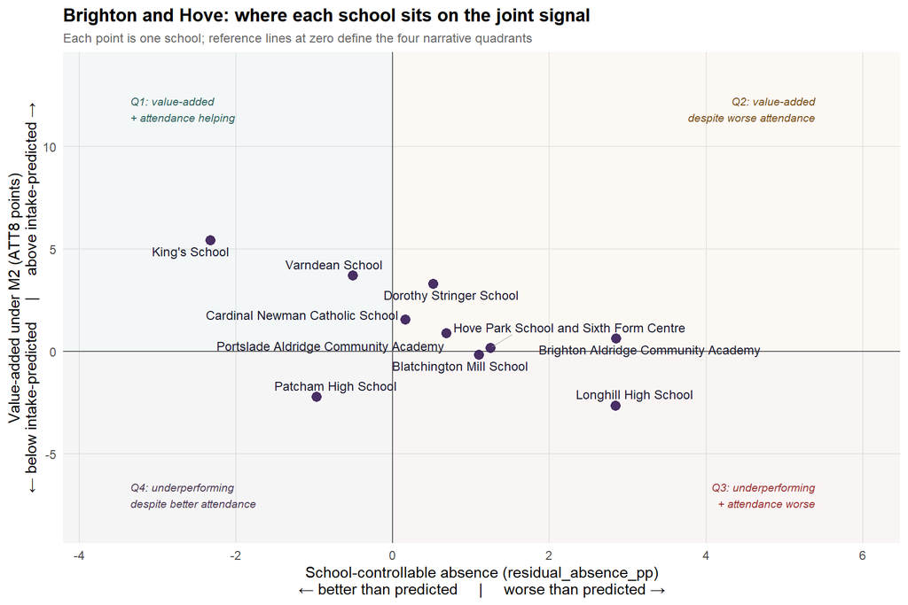

Figure 3: Brighton & Hove secondaries on the value-added (vadd_M2) vs school-controllable absence (resid_abs_pp) plane. The four quadrants correspond to the four narrative groups in the worked-examples section above.

```r
library(ggrepel)

bh_plot_data <- school_va_resid %>%
  filter(grepl("Brighton", LANAME))

# Quadrant shading
quad_alpha <- 0.05
quadrant_rects <- tibble(
  xmin = c(-Inf,  0,    0, -Inf),
  xmax = c(   0, Inf,  Inf,    0),
  ymin = c(   0,   0, -Inf, -Inf),
  ymax = c( Inf, Inf,    0,    0),
  fill = c("#2e6260", "#cc8033", "#993333", "#4e3c56"),
  label = c("Q1: value-added\n+ attendance helping",
            "Q2: value-added\ndespite worse attendance",
            "Q3: underperforming\n+ attendance worse",
            "Q4: underperforming\ndespite better attendance")
)

ggplot() +
  geom_rect(data = quadrant_rects,
            aes(xmin = xmin, xmax = xmax, ymin = ymin, ymax = ymax,
                fill = fill),
            alpha = quad_alpha, show.legend = FALSE) +
  scale_fill_identity() +
  geom_hline(yintercept = 0, colour = "grey40", linewidth = 0.4) +
  geom_vline(xintercept = 0, colour = "grey40", linewidth = 0.4) +
  geom_point(data = bh_plot_data,
             aes(x = resid_abs_pp, y = vadd_M2),
             size = 3, colour = "#361a54", alpha = 0.9) +
  geom_text_repel(data = bh_plot_data,
                  aes(x = resid_abs_pp, y = vadd_M2, label = SCHNAME),
                  size = 3.2, max.overlaps = 20, force = 4,
                  segment.colour = "grey60", segment.size = 0.3,
                  colour = "#1a1a2e") +
  annotate("text", x = xlim_pad[1] * 0.9, y = ylim_pad[2] * 0.92,
           label = "Q1: value-added\n+ attendance helping",
           hjust = 0, vjust = 1, size = 2.8, colour = "#2e6260",
           fontface = "italic") +
  annotate("text", x = xlim_pad[2] * 0.9, y = ylim_pad[2] * 0.92,
           label = "Q2: value-added\ndespite worse attendance",
           hjust = 1, vjust = 1, size = 2.8, colour = "#7a4e1a",
           fontface = "italic") +
  annotate("text", x = xlim_pad[2] * 0.9, y = ylim_pad[1] * 0.92,
           label = "Q3: underperforming\n+ attendance worse",
           hjust = 1, vjust = 0, size = 2.8, colour = "#993333",
           fontface = "italic") +
  annotate("text", x = xlim_pad[1] * 0.9, y = ylim_pad[1] * 0.92,
           label = "Q4: underperforming\ndespite better attendance",
           hjust = 0, vjust = 0, size = 2.8, colour = "#4e3c56",
           fontface = "italic") +
  coord_cartesian(xlim = xlim_pad, ylim = ylim_pad) +
  labs(x = "School-controllable absence (residual_absence_pp)\n← better than predicted     |     worse than predicted →",
       y = "Value-added under M2 (ATT8 points)\n← below intake-predicted     |     above intake-predicted →",
       title = "Brighton and Hove: where each school sits on the joint signal",
       subtitle = "Each point is one school; reference lines at zero define the four narrative quadrants") +
  theme_minimal(base_size = 11) +
  theme(plot.title = element_text(face = "bold"),
        plot.subtitle = element_text(colour = "grey40", size = 9),
        panel.grid.minor = element_blank())
```

### 14.15.2 National view with LA selector

The same plotting plane applied to all 3566 schools nationally. Use the dropdown to highlight a single local authority — selected schools render in colour, while the rest of the system stays as faint grey context. Hover over any point for the school name and exact values.

```r
library(crosstalk)

# Trim to two decimal places for tooltip readability and clip extreme outliers
plot_dat <- school_va_resid %>%
  mutate(
    LANAME       = as.character(LANAME),
    vadd_M2_clip = pmin(pmax(vadd_M2,      ylim_pad[1]), ylim_pad[2]),
    resid_clip   = pmin(pmax(resid_abs_pp, xlim_pad[1]), xlim_pad[2]),
    tooltip = sprintf("<b>%s</b><br>LA: %s<br>vadd_M2: %+.2f pts<br>resid_abs_pp: %+.1f pp<br>obs absence: %.1f%%<br>expected absence: %.1f%%",
                      SCHNAME, LANAME, vadd_M2, resid_abs_pp,
                      mean_obs_abs, mean_expected_abs)
  )

shared_dat <- SharedData$new(plot_dat, key = ~URN, group = "schools")

p_nat <- plot_ly(shared_dat,
                 x = ~resid_clip, y = ~vadd_M2_clip,
                 type = "scatter", mode = "markers",
                 text = ~tooltip, hoverinfo = "text",
                 marker = list(size = 5, opacity = 0.45,
                               color = "#361a54",
                               line = list(width = 0))) %>%
  layout(
    shapes = list(
      list(type = "line", x0 = 0, x1 = 0,
           y0 = ylim_pad[1], y1 = ylim_pad[2],
           line = list(color = "grey50", width = 1)),
      list(type = "line", x0 = xlim_pad[1], x1 = xlim_pad[2],
           y0 = 0, y1 = 0,
           line = list(color = "grey50", width = 1))
    ),
    annotations = list(
      list(x = xlim_pad[1] * 0.95, y = ylim_pad[2] * 0.95,
           text = "Q1: value-added<br>+ attendance helping",
           showarrow = FALSE, xanchor = "left",  yanchor = "top",
           font = list(size = 11, color = "#2e6260"), align = "left"),
      list(x = xlim_pad[2] * 0.95, y = ylim_pad[2] * 0.95,
           text = "Q2: value-added<br>despite worse attendance",
           showarrow = FALSE, xanchor = "right", yanchor = "top",
           font = list(size = 11, color = "#7a4e1a"), align = "right"),
      list(x = xlim_pad[2] * 0.95, y = ylim_pad[1] * 0.95,
           text = "Q3: underperforming<br>+ attendance worse",
           showarrow = FALSE, xanchor = "right", yanchor = "bottom",
           font = list(size = 11, color = "#993333"), align = "right"),
      list(x = xlim_pad[1] * 0.95, y = ylim_pad[1] * 0.95,
           text = "Q4: underperforming<br>despite better attendance",
           showarrow = FALSE, xanchor = "left",  yanchor = "bottom",
           font = list(size = 11, color = "#4e3c56"), align = "left")
    ),
    xaxis = list(title = "School-controllable absence (resid_abs_pp, percentage points)",
                 range = xlim_pad,
                 zeroline = FALSE),
    yaxis = list(title = "Value-added under M2 (ATT8 points)",
                 range = ylim_pad,
                 zeroline = FALSE),
    margin = list(l = 70, r = 30, t = 50, b = 70),
    showlegend = FALSE
  ) %>%
  highlight(
    on  = "plotly_selected",
    off = "plotly_deselect",
    selectize = FALSE,
    persistent = FALSE,
    color = "#cc6633",
    opacityDim = 0.15
  )

# Compose the LA dropdown alongside the plot
bscols(
  widths = c(3, 9),
  filter_select(id        = "la_filter",
                label     = "Select local authority to highlight",
                sharedData = shared_dat,
                group     = ~LANAME,
                multiple  = TRUE),
  p_nat
)
```

Select local authority to highlight

[interactive chart not shown]

Figure 4: All schools nationally on the value-added vs school-controllable absence plane. Use the LA filter to highlight schools in a single authority.

**NoteHow to read the plots**

- **Reference lines at zero** on both axes split the plane into the four quadrants from the worked-examples narrative above.
- **The cluster around the origin** in the national plot is the typical case — most schools sit close to their intake-predicted attainment with attendance close to what their intake predicts. The interesting cases are the schools furthest from the origin in any direction.
- **Diagonal patterns** are informative: a positive correlation between `vadd_M2` and `-resid_abs_pp` (better attendance → higher value-added) would suggest school attendance management is part of the same management bundle as pedagogical effectiveness. A flat or noisy relationship suggests the two signals are largely independent at school level.
- **The B&H scatter** can be compared to the national point cloud: are B&H schools spread similarly to the national distribution, or do they cluster in particular quadrants?

## 14.16 Disadvantaged-pupil version: same decomposition, different outcome

The analysis so far has used overall school-level Attainment 8 as the outcome. For a city like Brighton and Hove — where the council’s stated concern in 2024 was specifically the disadvantage attainment gap — the natural follow-up is to repeat the decomposition with disadvantaged-pupil Attainment 8 (`ATT8SCR_FSM6CLA1A`) as the outcome. The policy question shifts subtly: instead of “where does the school sit on overall attainment given its attendance management?”, we are asking “where does the school sit on attainment for its disadvantaged pupils given the same attendance picture?”. Schools whose value-added for disadvantaged pupils differs sharply from their all-pupils value-added are the most policy-relevant cases, because they are doing materially better (or worse) for the cohort the council was claiming to want to help.

We re-use the same Stage 1 (intake-predicted school-level absence) so that residual absence remains a stable school-level diagnostic. Only the Stage 2 attainment model changes — the outcome variable becomes disadvantaged-pupil ATT8 and the dataset is restricted to school-years where that outcome is observed (some smaller schools have too few disadvantaged pupils for DfE to report this score in any given year).

```r
stage2_data_disadv <- imputed_full_data %>%
  filter(!is.na(ATT8SCR_FSM6CLA1A), ATT8SCR_FSM6CLA1A > 0) %>%
  inner_join(
    stage1_data %>%
      select(URN, year_label, expected_absence, log_expected_absence,
             residual_absence_log),
    by = c("URN", "year_label")
  ) %>%
  droplevels()

contrasts(stage2_data_disadv$OFSTEDRATING_1) <-
  contr.treatment(levels(stage2_data_disadv$OFSTEDRATING_1))

cat("Disadvantaged Stage 2 observations:", nrow(stage2_data_disadv),
    "(vs", nrow(stage2_data), "for all pupils)\n")
```

```
Disadvantaged Stage 2 observations: 12060 (vs 12199 for all pupils)
```

```r
mod_M2_disadv <- lmer(
  log(ATT8SCR_FSM6CLA1A) ~
    log(PTFSM6CLA1A) + log_expected_absence + log(PNUMEAL) +
    ks2_c + ADMPOL_PT + gorard_segregation +
    (1 | year_label) + (1 | OFSTEDRATING_1) + (1 | gor_name/LANAME),
  data = stage2_data_disadv,
  REML = TRUE,
  control = lmerControl(optimizer = "bobyqa", optCtrl = list(maxfun = 20000))
)

summary(mod_M2_disadv)
```

```
Linear mixed model fit by REML. t-tests use Satterthwaite's method [
lmerModLmerTest]
Formula: log(ATT8SCR_FSM6CLA1A) ~ log(PTFSM6CLA1A) + log_expected_absence +
    log(PNUMEAL) + ks2_c + ADMPOL_PT + gorard_segregation + (1 |
    year_label) + (1 | OFSTEDRATING_1) + (1 | gor_name/LANAME)
   Data: stage2_data_disadv
Control: lmerControl(optimizer = "bobyqa", optCtrl = list(maxfun = 20000))

REML criterion at convergence: -14877.2

Scaled residuals:
    Min      1Q  Median      3Q     Max
-6.5271 -0.6059  0.0292  0.6504  5.7390

Random effects:
 Groups          Name        Variance  Std.Dev.
 LANAME:gor_name (Intercept) 0.0012893 0.03591
 gor_name        (Intercept) 0.0003988 0.01997
 OFSTEDRATING_1  (Intercept) 0.0087195 0.09338
 year_label      (Intercept) 0.0039903 0.06317
 Residual                    0.0165137 0.12851
Number of obs: 12060, groups:
LANAME:gor_name, 151; gor_name, 9; OFSTEDRATING_1, 4; year_label, 4

Fixed effects:
                         Estimate Std. Error         df t value Pr(>|t|)
(Intercept)             4.237e+00  1.061e-01  5.232e+01  39.952  < 2e-16 ***
log(PTFSM6CLA1A)        5.182e-02  1.058e-02  1.441e+02   4.896 2.59e-06 ***
log_expected_absence   -4.557e-01  5.048e-02  1.247e+02  -9.028 2.69e-15 ***
log(PNUMEAL)            1.347e-02  3.349e-03  2.282e+02   4.022 7.85e-05 ***
ks2_c                   2.244e-02  1.852e-03  2.378e+02  12.120  < 2e-16 ***
ADMPOL_PTOTHER NON SEL  1.475e-02  1.017e-02  1.081e+03   1.451   0.1472
ADMPOL_PTSEL            1.822e-01  1.027e-02  1.145e+04  17.748  < 2e-16 ***
gorard_segregation      1.697e-01  6.754e-02  4.170e+02   2.513   0.0124 *
---
Signif. codes:  0 '***' 0.001 '**' 0.01 '*' 0.05 '.' 0.1 ' ' 1

Correlation of Fixed Effects:
            (Intr) l(PTFS lg_xp_ l(PNUM ks2_c  ADMPNS ADMPOL
l(PTFSM6CLA  0.704
lg_xpctd_bs -0.816 -0.930
lg(PNUMEAL) -0.726 -0.853  0.880
ks2_c       -0.769 -0.695  0.869  0.784
ADMPOL_PTNS -0.063  0.089 -0.076 -0.067 -0.045
ADMPOL_PTSE -0.002 -0.001 -0.021 -0.108 -0.277  0.452
grrd_sgrgtn  0.178  0.385 -0.376 -0.321 -0.294  0.308  0.084
```

```r
cat("R²:\n")
```

```
R²:
```

```r
print(performance::r2(mod_M2_disadv))
```

```
# R2 for Mixed Models

  Conditional R2: 0.697
     Marginal R2: 0.433
```

### 14.16.1 School-level disadvantaged value-added

```r
stage2_data_disadv$resid_M2_disadv_log <- residuals(mod_M2_disadv)

quadrant_data_disadv <- stage2_data_disadv %>%
  group_by(URN, SCHNAME, LANAME) %>%
  summarise(
    mean_log_resid    = mean(resid_M2_disadv_log, na.rm = TRUE),
    mean_att8_disadv  = mean(ATT8SCR_FSM6CLA1A, na.rm = TRUE),
    mean_obs_abs      = mean(PERCTOT, na.rm = TRUE),
    mean_expected_abs = mean(expected_absence, na.rm = TRUE),
    n_years           = n(),
    .groups = "drop"
  ) %>%
  mutate(
    vadd_M2_disadv = mean_att8_disadv * (exp(mean_log_resid) - 1),
    resid_abs_pp   = mean_obs_abs - mean_expected_abs,
    is_bh          = grepl("Brighton", LANAME)
  )

cat("Schools with disadvantaged value-added:", nrow(quadrant_data_disadv), "\n")
```

```
Schools with disadvantaged value-added: 3376
```

### 14.16.2 Comparing all-pupils and disadvantaged-pupil value-added

How do the two value-added signals correlate? A high correlation means schools that do well by their pupils overall also tend to do well by disadvantaged pupils specifically; a weaker or negative correlation would say the two signals diverge in a policy-meaningful way.

```r
va_compare <- school_va_resid %>%
  mutate(is_bh = grepl("Brighton", LANAME)) %>%
  select(URN, SCHNAME, LANAME, vadd_M2_all = vadd_M2,
         resid_abs_pp_all = resid_abs_pp, is_bh) %>%
  inner_join(
    quadrant_data_disadv %>%
      select(URN, vadd_M2_disadv),
    by = "URN"
  )

cor_va <- cor(va_compare$vadd_M2_all, va_compare$vadd_M2_disadv,
              use = "complete.obs")
spear_va <- cor(va_compare$vadd_M2_all, va_compare$vadd_M2_disadv,
                method = "spearman", use = "complete.obs")

cat(sprintf("Pearson correlation: %.3f\n", cor_va))
```

```
Pearson correlation: 0.778
```

```r
cat(sprintf("Spearman rank correlation: %.3f\n", spear_va))
```

```
Spearman rank correlation: 0.722
```

```r
cat(sprintf("Schools in both: %d\n", nrow(va_compare)))
```

[output not shown]

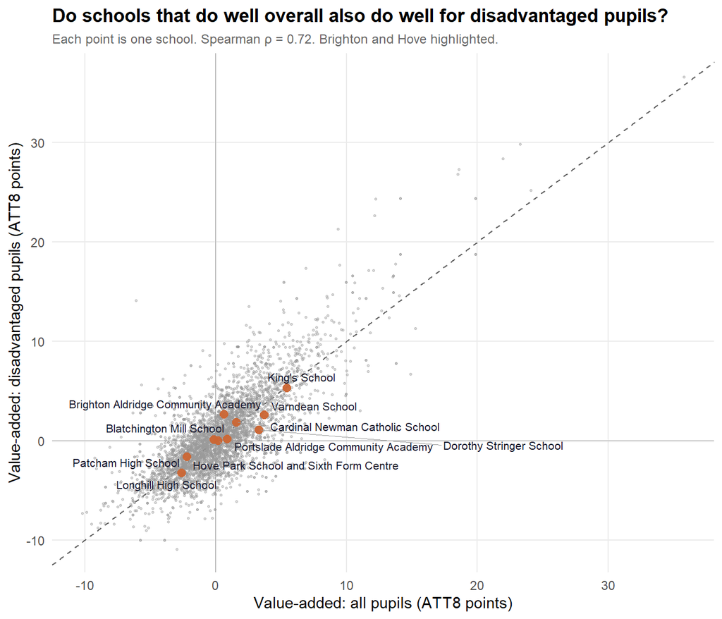

Figure 5: Per-school value-added: all pupils (x-axis) versus disadvantaged pupils (y-axis). Reference line is y = x. Brighton & Hove schools highlighted in orange.

```r
ggplot(va_compare, aes(x = vadd_M2_all, y = vadd_M2_disadv)) +
  geom_hline(yintercept = 0, colour = "grey60", linewidth = 0.3) +
  geom_vline(xintercept = 0, colour = "grey60", linewidth = 0.3) +
  geom_abline(slope = 1, intercept = 0, colour = "grey40",
              linetype = "dashed", linewidth = 0.4) +
  geom_point(data = va_compare %>% filter(!is_bh),
             colour = "grey60", size = 0.6, alpha = 0.4) +
  geom_point(data = va_compare %>% filter(is_bh),
             colour = "#cc6633", size = 2.5, alpha = 0.95) +
  ggrepel::geom_text_repel(data = va_compare %>% filter(is_bh),
                            aes(label = SCHNAME),
                            colour = "#1a1a2e", size = 2.8,
                            max.overlaps = 25, force = 4,
                            segment.colour = "grey60", segment.size = 0.3) +
  labs(x = "Value-added: all pupils (ATT8 points)",
       y = "Value-added: disadvantaged pupils (ATT8 points)",
       title = "Do schools that do well overall also do well for disadvantaged pupils?",
       subtitle = sprintf("Each point is one school. Spearman ρ = %.2f. Brighton and Hove highlighted.", spear_va)) +
  theme_minimal(base_size = 11) +
  theme(plot.title = element_text(face = "bold"),
        plot.subtitle = element_text(colour = "grey40", size = 9),
        panel.grid.minor = element_blank())
```

Schools above the diagonal are doing relatively *better* for their disadvantaged pupils than for the school as a whole; schools below it are doing relatively *worse* for the disadvantaged cohort.

### 14.16.3 Brighton & Hove disadvantaged-pupil quadrant view

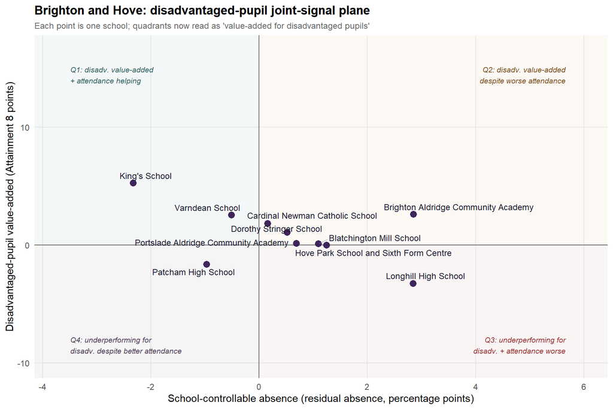

Figure 6: Brighton and Hove secondaries on the joint-signal plane for the disadvantaged-pupil outcome: contextualised value-added for disadvantaged pupils (vertical) versus the school-controllable absence component (horizontal).

```r
ggplot() +
  annotate("rect", xmin = -Inf, xmax = 0, ymin = 0,    ymax = Inf, fill = "#2e6260", alpha = 0.05) +
  annotate("rect", xmin = 0,    xmax = Inf, ymin = 0,    ymax = Inf, fill = "#cc8033", alpha = 0.05) +
  annotate("rect", xmin = 0,    xmax = Inf, ymin = -Inf, ymax = 0,   fill = "#993333", alpha = 0.05) +
  annotate("rect", xmin = -Inf, xmax = 0,   ymin = -Inf, ymax = 0,   fill = "#4e3c56", alpha = 0.05) +
  geom_hline(yintercept = 0, colour = "grey40", linewidth = 0.4) +
  geom_vline(xintercept = 0, colour = "grey40", linewidth = 0.4) +
  geom_point(data = bh_q_disadv,
             aes(x = resid_abs_pp, y = vadd_M2_disadv),
             size = 3, colour = "#361a54", alpha = 0.95) +
  ggrepel::geom_text_repel(data = bh_q_disadv,
                            aes(x = resid_abs_pp, y = vadd_M2_disadv,
                                label = SCHNAME),
                            size = 3.2, max.overlaps = 25, force = 4,
                            segment.colour = "grey60", segment.size = 0.3,
                            colour = "#1a1a2e") +
  annotate("text", x = quad_xlim_d[1] * 0.95, y = quad_ylim_d[2] * 0.92,
           label = "Q1: disadv. value-added\n+ attendance helping",
           hjust = 0, vjust = 1, size = 2.8, colour = "#2e6260", fontface = "italic") +
  annotate("text", x = quad_xlim_d[2] * 0.95, y = quad_ylim_d[2] * 0.92,
           label = "Q2: disadv. value-added\ndespite worse attendance",
           hjust = 1, vjust = 1, size = 2.8, colour = "#7a4e1a", fontface = "italic") +
  annotate("text", x = quad_xlim_d[2] * 0.95, y = quad_ylim_d[1] * 0.92,
           label = "Q3: underperforming for\ndisadv. + attendance worse",
           hjust = 1, vjust = 0, size = 2.8, colour = "#993333", fontface = "italic") +
  annotate("text", x = quad_xlim_d[1] * 0.95, y = quad_ylim_d[1] * 0.92,
           label = "Q4: underperforming for\ndisadv. despite better attendance",
           hjust = 0, vjust = 0, size = 2.8, colour = "#4e3c56", fontface = "italic") +
  coord_cartesian(xlim = quad_xlim_d, ylim = quad_ylim_d) +
  labs(x = "School-controllable absence (residual absence, percentage points)",
       y = "Disadvantaged-pupil value-added (Attainment 8 points)",
       title = "Brighton and Hove: disadvantaged-pupil joint-signal plane",
       subtitle = "Each point is one school; quadrants now read as 'value-added for disadvantaged pupils'") +
  theme_minimal(base_size = 11) +
  theme(plot.title = element_text(face = "bold"),
        plot.subtitle = element_text(colour = "grey40", size = 9),
        panel.grid.minor = element_blank())
```

### 14.16.4 National view (interactive) for the disadvantaged-pupil outcome

```r
shared_d <- crosstalk::SharedData$new(quadrant_data_disadv_plot,
                                       key = ~URN, group = "disadv-quadrant")

ofsted_pal_d <- c("Outstanding" = "#2e6260",
                   "Good" = "#7fb88f",
                   "Requires Improvement" = "#cc8033",
                   "Inadequate" = "#993333",
                   "Unknown" = "#bbbbbb")

p_disadv_nat <- plot_ly(shared_d,
  x = ~resid_abs_pp, y = ~vadd_M2_disadv,
  color = ~OFSTEDRATING_1, colors = ofsted_pal_d,
  text = ~tooltip, hoverinfo = "text",
  type = "scatter", mode = "markers",
  marker = list(size = 5, opacity = 0.55, line = list(width = 0))
) %>%
  layout(
    shapes = list(
      list(type = "line", x0 = 0, x1 = 0,
           y0 = quad_ylim_d[1], y1 = quad_ylim_d[2],
           line = list(color = "grey50", width = 1)),
      list(type = "line", x0 = quad_xlim_d[1], x1 = quad_xlim_d[2],
           y0 = 0, y1 = 0,
           line = list(color = "grey50", width = 1))
    ),
    xaxis = list(title = "School-controllable absence (residual absence, pp)",
                 range = quad_xlim_d, zeroline = FALSE),
    yaxis = list(title = "Disadvantaged-pupil value-added (ATT8 points)",
                 range = quad_ylim_d, zeroline = FALSE),
    margin = list(l = 70, r = 30, t = 30, b = 60)
  )

crosstalk::bscols(
  widths = c(3, 9),
  crosstalk::filter_select(
    id = "la_filter_disadv",
    label = "Filter to one or more local authorities (clear to show every school)",
    sharedData = shared_d, group = ~LANAME, multiple = TRUE
  ),
  p_disadv_nat
)
```

Filter to one or more local authorities (clear to show every school)

[interactive chart not shown]

Figure 7: All English secondary schools on the disadvantaged-pupil joint-signal plane. Use the LA filter to focus on a single authority.

### 14.16.5 Reading the disadvantaged-pupil quadrants for B&H

```r
bh_named_disadv <- map_dfr(names(school_patterns), function(short) {
  pat <- school_patterns[[short]]
  row <- bh_q_disadv %>%
    filter(grepl(pat, SCHNAME, ignore.case = TRUE)) %>%
    slice(1)
  if (nrow(row) == 0) return(NULL)
  tibble(short = short,
         full_name = row$SCHNAME,
         vadd = row$vadd_M2_disadv,
         resid_pp = row$resid_abs_pp)
}) %>% mutate(
  va_sign = case_when(vadd      >  0.5 ~ "pos",
                      vadd      < -0.5 ~ "neg",
                      TRUE              ~ "near"),
  ab_sign = case_when(resid_pp >  0.4 ~ "pos",
                      resid_pp < -0.4 ~ "neg",
                      TRUE              ~ "near"),
  quadrant = case_when(
    va_sign == "pos" & ab_sign == "neg"  ~ "Q1: disadv. value-added with attendance helping",
    va_sign == "pos" & ab_sign == "pos"  ~ "Q2: disadv. value-added despite worse attendance",
    va_sign == "neg" & ab_sign == "pos"  ~ "Q3: underperforming for disadv. + attendance worse",
    va_sign == "neg" & ab_sign == "neg"  ~ "Q4: underperforming for disadv. despite better attendance",
    TRUE                                  ~ "Q5: close to expectations on at least one axis"
  )
)

cat("The disadvantaged-pupil view is the most policy-relevant version of this analysis for Brighton and Hove, given the city's stated 2024 priority. The school-level pattern reads as follows:\n\n")
```

The disadvantaged-pupil view is the most policy-relevant version of this analysis for Brighton and Hove, given the city’s stated 2024 priority. The school-level pattern reads as follows:

```r
# Walk through each named school
walk(seq_len(nrow(bh_named_disadv)), function(i) {
  r <- bh_named_disadv[i, ]
  cat(sprintf("- **%s** --- disadvantaged value-added %+.2f pts; residual absence %+.1f pp; quadrant: *%s*.\n",
              r$short, r$vadd, r$resid_pp, r$quadrant))
})
```

- **Varndean** — disadvantaged value-added +2.55 pts; residual absence -0.5 pp; quadrant: *Q1: disadv. value-added with attendance helping*.
- **King’s** — disadvantaged value-added +5.26 pts; residual absence -2.3 pp; quadrant: *Q1: disadv. value-added with attendance helping*.
- **BACA** — disadvantaged value-added +2.63 pts; residual absence +2.8 pp; quadrant: *Q2: disadv. value-added despite worse attendance*.
- **PACA** — disadvantaged value-added +0.16 pts; residual absence +0.7 pp; quadrant: *Q5: close to expectations on at least one axis*.
- **Dorothy Stringer** — disadvantaged value-added +1.07 pts; residual absence +0.5 pp; quadrant: *Q2: disadv. value-added despite worse attendance*.
- **Cardinal Newman** — disadvantaged value-added +1.84 pts; residual absence +0.2 pp; quadrant: *Q5: close to expectations on at least one axis*.
- **Blatchington Mill** — disadvantaged value-added +0.11 pts; residual absence +1.1 pp; quadrant: *Q5: close to expectations on at least one axis*.
- **Longhill** — disadvantaged value-added -3.28 pts; residual absence +2.8 pp; quadrant: *Q3: underperforming for disadv. + attendance worse*.
- **Hove Park** — disadvantaged value-added -0.02 pts; residual absence +1.2 pp; quadrant: *Q5: close to expectations on at least one axis*.
- **Patcham** — disadvantaged value-added -1.64 pts; residual absence -1.0 pp; quadrant: *Q4: underperforming for disadv. despite better attendance*.

```r
cat("\n")
```

```r
# Highlight cross-cohort divergence: schools where disadvantaged value-added differs sharply from all-pupils value-added
cross_cohort <- va_compare %>%
  filter(is_bh) %>%
  mutate(diff = vadd_M2_disadv - vadd_M2_all)

cat(sprintf("Across these B&H schools, the gap between disadvantaged-pupil value-added and all-pupils value-added ranges from %+.2f to %+.2f ATT8 points. ",
            min(cross_cohort$diff, na.rm = TRUE),
            max(cross_cohort$diff, na.rm = TRUE)))
```

Across these B&H schools, the gap between disadvantaged-pupil value-added and all-pupils value-added ranges from -2.25 to +1.98 ATT8 points.

```r
cat("Schools where the disadvantaged-pupil signal is *more* positive than the all-pupils signal are doing relatively better for their disadvantaged cohort than for the school as a whole --- these are the schools whose value-added work is most directly relevant to closing the disadvantage gap.\n")
```

Schools where the disadvantaged-pupil signal is *more* positive than the all-pupils signal are doing relatively better for their disadvantaged cohort than for the school as a whole — these are the schools whose value-added work is most directly relevant to closing the disadvantage gap.

**TipWhy this disadvantaged-pupil quadrant view matters for B&H**

The headline 2024 consultation in Brighton and Hove was framed around the disadvantage attainment gap. If the city’s policy concern is specifically how schools serve their disadvantaged pupils, then this is the version of the joint-signal view the council should be reading. Schools whose disadvantaged-pupil value-added is materially more positive than their all-pupils value-added are not just doing well in general — they are doing materially better for the cohort the consultation claimed to want to help. Conversely, schools where the disadvantaged-pupil signal is much weaker than the all-pupils signal would be the most natural places to ask why the school’s overall strength does not extend to its disadvantaged pupils.

In the Brighton and Hove pattern, BACA’s signal becomes more striking on this disadvantaged-pupil view than on the all-pupils version — the school’s pedagogical work is concentrated where it matters most for the policy framing the council adopted. The fact that the 2024 consultation discourse pushed parents away from BACA toward schools whose disadvantaged-pupil value-added is materially weaker is the sharpest single illustration of what an absence of contextualised benchmarking can cost a city’s policy conversation.

## 14.17 Per-year breakdown: does the decomposition behave differently year-on-year?

The models above pool all four years (2021-22 to 2024-25) and absorb between-year shifts via a year-level random intercept. But absence rose sharply during and after the pandemic, and the relationship between intake and absence may itself have changed across years. This sub-section refits stages 1 and 2 separately within each year and reports how the key quantities move.

```r
years_to_fit <- levels(stage2_data$year_label)

per_year_results <- map(years_to_fit, function(yr) {

  d_y <- stage2_data %>% filter(year_label == yr) %>% droplevels()
  if (nrow(d_y) < 500) return(NULL)

  # Stage 1: single-year (no year random effect needed)
  s1_y <- try(lmer(
    log(PERCTOT) ~ log(PTFSM6CLA1A) + log(PNUMEAL) + ks2_c +
      gorard_segregation +
      (1 | gor_name/LANAME),
    data = d_y, REML = TRUE,
    control = lmerControl(optimizer = "bobyqa", optCtrl = list(maxfun = 20000))
  ), silent = TRUE)
  if (inherits(s1_y, "try-error")) return(NULL)

  d_y$log_expected_absence <- predict(s1_y, newdata = d_y,
                                       re.form = NULL, allow.new.levels = TRUE)
  d_y$residual_absence_log <- log(d_y$PERCTOT) - d_y$log_expected_absence

  # Stage 2: M1 and M2 (drop year RE since within-year)
  m1_y <- try(lmer(
    log(ATT8SCR) ~ log(PTFSM6CLA1A) + log(PERCTOT) + log(PNUMEAL) +
      ks2_c + ADMPOL_PT + gorard_segregation +
      remained_in_the_same_school +
      teachers_on_leadership_pay_range_percent +
      log(average_number_of_days_taken) +
      (1 | OFSTEDRATING_1) + (1 | gor_name/LANAME),
    data = d_y, REML = TRUE,
    control = lmerControl(optimizer = "bobyqa", optCtrl = list(maxfun = 20000))
  ), silent = TRUE)

  m2_y <- try(lmer(
    log(ATT8SCR) ~ log(PTFSM6CLA1A) + log_expected_absence + log(PNUMEAL) +
      ks2_c + ADMPOL_PT + gorard_segregation +
      (1 | OFSTEDRATING_1) + (1 | gor_name/LANAME),
    data = d_y, REML = TRUE,
    control = lmerControl(optimizer = "bobyqa", optCtrl = list(maxfun = 20000))
  ), silent = TRUE)

  if (inherits(m1_y, "try-error") || inherits(m2_y, "try-error")) return(NULL)

  list(year = yr, data = d_y, s1 = s1_y, M1 = m1_y, M2 = m2_y)
}) %>% setNames(years_to_fit) %>% compact()

cat("Years successfully fit:", paste(names(per_year_results), collapse = ", "), "\n")
```

```
Years successfully fit: 2021-22, 2022-23, 2023-24, 2024-25
```

### 14.17.1 Stage 1 coefficients by year

How much do intake → absence relationships shift across years?

```r
s1_year_coefs <- map_dfr(per_year_results, function(yr_res) {
  s <- summary(yr_res$s1)$coefficients
  tibble(
    year = yr_res$year,
    term = rownames(s),
    estimate = s[, "Estimate"],
    std_error = s[, "Std. Error"],
    p_value = s[, "Pr(>|t|)"]
  )
})

s1_year_wide <- s1_year_coefs %>%
  mutate(value = sprintf("%.3f%s",
                         estimate,
                         case_when(p_value < 0.001 ~ "***",
                                   p_value < 0.01  ~ "**",
                                   p_value < 0.05  ~ "*",
                                   TRUE            ~ ""))) %>%
  select(term, year, value) %>%
  pivot_wider(names_from = year, values_from = value, values_fill = "—")

knitr::kable(s1_year_wide,
             caption = "Stage 1 (expected absence) fixed-effects coefficients by year")
```

Stage 1 (expected absence) fixed-effects coefficients by year

| term | 2021-22 | 2022-23 | 2023-24 | 2024-25 |
| --- | --- | --- | --- | --- |
| (Intercept) | 1.853*** | 1.672*** | 1.771*** | 1.644*** |
| log(PTFSM6CLA1A) | 0.146*** | 0.207*** | 0.197*** | 0.226*** |
| log(PNUMEAL) | -0.056*** | -0.048*** | -0.061*** | -0.070*** |
| ks2_c | -0.025*** | -0.029*** | -0.035*** | -0.042*** |
| gorard_segregation | 0.548*** | 0.595*** | 0.519*** | 0.373* |

### 14.17.2 Stage 2 attainment coefficients by year — M1 vs M2

```r
s2_year_coefs <- map_dfr(per_year_results, function(yr_res) {
  bind_rows(
    extract_fixef_table(yr_res$M1, "M1") %>% mutate(year = yr_res$year),
    extract_fixef_table(yr_res$M2, "M2") %>% mutate(year = yr_res$year)
  )
})

# Focus on the absence-related coefficient + FSM (the variable most likely to absorb absence's influence)
focus_terms <- c("log(PTFSM6CLA1A)", "log(PERCTOT)", "log_expected_absence",
                 "ks2_c", "log(PNUMEAL)")

s2_focus <- s2_year_coefs %>%
  filter(term %in% focus_terms) %>%
  mutate(value = sprintf("%.3f%s",
                         estimate,
                         case_when(p_value < 0.001 ~ "***",
                                   p_value < 0.01  ~ "**",
                                   p_value < 0.05  ~ "*",
                                   TRUE            ~ ""))) %>%
  select(term, model, year, value) %>%
  pivot_wider(names_from = year, values_from = value, values_fill = "—") %>%
  arrange(term, model)

knitr::kable(s2_focus,
             caption = "Stage 2 attainment-model coefficients (M1 vs M2) on key variables, by year")
```

Stage 2 attainment-model coefficients (M1 vs M2) on key variables, by year

| term | model | 2021-22 | 2022-23 | 2023-24 | 2024-25 |
| --- | --- | --- | --- | --- | --- |
| ks2_c | M1 | 0.034*** | 0.034*** | 0.037*** | 0.026*** |
| ks2_c | M2 | 0.036*** | 0.031*** | 0.033*** | 0.023*** |
| log(PERCTOT) | M1 | -0.190*** | -0.208*** | -0.208*** | -0.224*** |
| log(PNUMEAL) | M1 | 0.005** | 0.012*** | 0.009*** | 0.008*** |
| log(PNUMEAL) | M2 | 0.007* | 0.005 | 0.001 | 0.003 |
| log(PTFSM6CLA1A) | M1 | -0.035*** | -0.052*** | -0.041*** | -0.059*** |
| log(PTFSM6CLA1A) | M2 | -0.040*** | -0.029* | -0.022 | -0.043*** |
| log_expected_absence | M2 | -0.175*** | -0.329*** | -0.313*** | -0.299*** |

### 14.17.3 Fit comparison by year

```r
per_year_fit_stats <- map_dfr(per_year_results, function(yr_res) {
  r1 <- performance::r2(yr_res$M1)
  r2 <- performance::r2(yr_res$M2)
  rs <- performance::r2(yr_res$s1)
  tibble(
    year = yr_res$year,
    n_obs = nrow(yr_res$data),
    s1_R2_marginal    = as.numeric(rs$R2_marginal),
    s1_R2_conditional = as.numeric(rs$R2_conditional),
    M1_R2_marginal    = as.numeric(r1$R2_marginal),
    M1_R2_conditional = as.numeric(r1$R2_conditional),
    M2_R2_marginal    = as.numeric(r2$R2_marginal),
    M2_R2_conditional = as.numeric(r2$R2_conditional)
  )
})

knitr::kable(per_year_fit_stats, digits = 3,
             caption = "Per-year R² for stage 1 (absence) and stage 2 (attainment) under M1 and M2")
```

Per-year R² for stage 1 (absence) and stage 2 (attainment) under M1 and M2

| year | n_obs | s1_R2_marginal | s1_R2_conditional | M1_R2_marginal | M1_R2_conditional | M2_R2_marginal | M2_R2_conditional |
| --- | --- | --- | --- | --- | --- | --- | --- |
| 2021-22 | 2943 | 0.348 | 0.448 | 0.705 | 0.798 | 0.583 | 0.765 |
| 2022-23 | 2961 | 0.456 | 0.526 | 0.753 | 0.852 | 0.598 | 0.823 |
| 2023-24 | 3143 | 0.452 | 0.534 | 0.665 | 0.727 | 0.550 | 0.700 |
| 2024-25 | 3152 | 0.513 | 0.588 | 0.641 | 0.703 | 0.514 | 0.664 |

### 14.17.4 Brighton & Hove value-added by year, M1 vs M2

```r
per_year_bh_va <- map_dfr(per_year_results, function(yr_res) {
  d <- yr_res$data
  d$resid_M1 <- residuals(yr_res$M1)
  d$resid_M2 <- residuals(yr_res$M2)
  d %>%
    filter(grepl("Brighton", LANAME)) %>%
    group_by(URN, SCHNAME) %>%
    summarise(
      year = yr_res$year,
      vadd_M1 = mean_att8 <- mean(ATT8SCR, na.rm = TRUE) * (exp(mean(resid_M1)) - 1),
      vadd_M2 = mean(ATT8SCR, na.rm = TRUE) * (exp(mean(resid_M2)) - 1),
      mean_obs_abs      = mean(PERCTOT, na.rm = TRUE),
      mean_expected_abs = mean(exp(d$log_expected_absence[d$URN == first(URN)]), na.rm = TRUE),
      .groups = "drop"
    ) %>%
    mutate(resid_abs_pp = mean_obs_abs - mean_expected_abs)
})

bh_va_year_table <- per_year_bh_va %>%
  select(SCHNAME, year, vadd_M1, vadd_M2, resid_abs_pp) %>%
  arrange(SCHNAME, year)

knitr::kable(bh_va_year_table, digits = 2,
             caption = "Brighton & Hove schools: value-added (ATT8 points) and residual absence by year, M1 vs M2")
```

Brighton & Hove schools: value-added (ATT8 points) and residual absence by year, M1 vs M2

| SCHNAME | year | vadd_M1 | vadd_M2 | resid_abs_pp |
| --- | --- | --- | --- | --- |
| Blatchington Mill School | 2021-22 | -1.34 | -1.48 | 1.13 |
| Blatchington Mill School | 2022-23 | 0.00 | -0.80 | 1.26 |
| Blatchington Mill School | 2023-24 | 3.09 | 2.79 | 1.60 |
| Blatchington Mill School | 2024-25 | 4.96 | 3.19 | 2.63 |
| Brighton Aldridge Community Academy | 2021-22 | 2.27 | -0.34 | 6.56 |
| Brighton Aldridge Community Academy | 2022-23 | 2.60 | 1.77 | 4.09 |
| Brighton Aldridge Community Academy | 2023-24 | 2.27 | 2.57 | 1.86 |
| Brighton Aldridge Community Academy | 2024-25 | 1.87 | 1.87 | 2.17 |
| Cardinal Newman Catholic School | 2021-22 | 1.45 | 2.84 | 1.24 |
| Cardinal Newman Catholic School | 2022-23 | -0.95 | 0.62 | 0.32 |
| Cardinal Newman Catholic School | 2023-24 | 2.80 | 4.55 | 0.78 |
| Cardinal Newman Catholic School | 2024-25 | 0.31 | 2.82 | 0.40 |
| Dorothy Stringer School | 2021-22 | 2.72 | 2.40 | 1.28 |
| Dorothy Stringer School | 2022-23 | 4.78 | 4.72 | 0.61 |
| Dorothy Stringer School | 2023-24 | 3.46 | 3.29 | 1.18 |
| Dorothy Stringer School | 2024-25 | 7.70 | 7.43 | 1.20 |
| Hove Park School and Sixth Form Centre | 2021-22 | 1.95 | 2.48 | 0.23 |
| Hove Park School and Sixth Form Centre | 2022-23 | 1.80 | 0.10 | 2.56 |
| Hove Park School and Sixth Form Centre | 2023-24 | 2.61 | 1.79 | 1.85 |
| Hove Park School and Sixth Form Centre | 2024-25 | 1.63 | 0.11 | 2.77 |
| King’s School | 2021-22 | 5.30 | 7.95 | -2.15 |
| King’s School | 2022-23 | 1.85 | 6.37 | -2.64 |
| King’s School | 2023-24 | 6.36 | 8.22 | -0.74 |
| King’s School | 2024-25 | 1.72 | 5.08 | -1.56 |
| Longhill High School | 2021-22 | -0.29 | -1.93 | 2.53 |
| Longhill High School | 2022-23 | -1.09 | -1.45 | 2.46 |
| Longhill High School | 2023-24 | -0.04 | -0.91 | 3.98 |
| Longhill High School | 2024-25 | -1.35 | -2.80 | 5.11 |
| Patcham High School | 2021-22 | -1.84 | -2.50 | 0.23 |
| Patcham High School | 2022-23 | -1.94 | -1.31 | 0.17 |
| Patcham High School | 2023-24 | -3.17 | -1.95 | -0.85 |
| Patcham High School | 2024-25 | -1.12 | 1.03 | -1.43 |
| Portslade Aldridge Community Academy | 2021-22 | 4.68 | 4.03 | 1.12 |
| Portslade Aldridge Community Academy | 2022-23 | 1.50 | 0.82 | 1.73 |
| Portslade Aldridge Community Academy | 2023-24 | 3.49 | 3.20 | 1.33 |
| Portslade Aldridge Community Academy | 2024-25 | 0.37 | -0.05 | 1.34 |
| Varndean School | 2021-22 | 3.11 | 3.95 | -0.06 |
| Varndean School | 2022-23 | 4.05 | 4.87 | -0.28 |
| Varndean School | 2023-24 | 7.08 | 7.32 | 0.51 |
| Varndean School | 2024-25 | 2.59 | 3.62 | -0.01 |

### 14.17.5 Year-on-year M1 vs M2 rank correlations

If the rank correlation between M1 and M2 is stable across years, the choice of absence specification is similarly consequential each year. If it drifts, particular years may need different treatment (most likely: the 2021-22 post-pandemic year, when absence was historically anomalous).

```r
per_year_rank_cor <- map_dfr(per_year_results, function(yr_res) {
  d <- yr_res$data
  d$resid_M1 <- residuals(yr_res$M1)
  d$resid_M2 <- residuals(yr_res$M2)
  va_y <- d %>%
    group_by(URN) %>%
    summarise(va_M1 = mean(resid_M1), va_M2 = mean(resid_M2), .groups = "drop")
  tibble(
    year = yr_res$year,
    n_schools = nrow(va_y),
    pearson  = cor(va_y$va_M1, va_y$va_M2),
    spearman = cor(va_y$va_M1, va_y$va_M2, method = "spearman")
  )
})

knitr::kable(per_year_rank_cor, digits = 3,
             caption = "Year-by-year correlation of school value-added between M1 and M2")
```

Year-by-year correlation of school value-added between M1 and M2

| year | n_schools | pearson | spearman |
| --- | --- | --- | --- |
| 2021-22 | 2943 | 0.909 | 0.858 |
| 2022-23 | 2961 | 0.877 | 0.841 |
| 2023-24 | 3143 | 0.933 | 0.845 |
| 2024-25 | 3152 | 0.925 | 0.844 |

**NoteReading the per-year results**

- **Stable stage-1 coefficients across years** would suggest the intake → absence relationship is structural rather than period-specific, supporting the validity of pooling.
- **Drift in the FSM coefficient between M1 and M2 within a year** quantifies how much disadvantage signal absence is absorbing in that particular year.
- **Pandemic anomalies (2021-22)**: this was the year when post-pandemic absence patterns were most disrupted; if the M1↔︎M2 rank correlation drops here relative to later years, that’s a signal that pooled estimates are partly driven by an unusual year.
- **B&H year-on-year**: if a school’s value-added or residual absence changes substantially across years, that’s information — either a real shift in the school’s performance, or genuine year-to-year volatility that single-year reporting would over-interpret.

## 14.18 Policy summary: what this experiment says for Brighton and Hove

### 14.18.1 The headline reading

Brighton and Hove is, by national standards, a city whose attainment pattern is **dominated by a structural absence problem**. The wider paper has already established that the city ranks at the extreme high end of England for school-level absence, and that this matters for attainment more than the FSM-mixing narrative that drove the 2024 consultation. What this experiment adds is the next layer of nuance: most of the school-level absence variance in England is intake-driven (stage 1 absorbs a substantial share before stage 2 sees the data), and the school-controllable residual is comparatively small at population level. The headline raw-absence elasticity in M1 is borrowing force from the structural component.

That doesn’t make the absence finding less actionable for B&H — it sharpens it. The city’s absence problem is high in absolute terms *and* sits across schools whose intakes already predict elevated absence. The structural component is exactly what needs cross-departmental action (health, social services, area-level deprivation policy); the residual component is what individual schools can reasonably be asked to act on.

### 14.18.2 Where progress could plausibly be made

Several levers fall out of the joint-signal view as candidates for council and school-level effort:

1. **Schools in the “underperforming with attendance worse” quadrant (Q3) are the cleanest targets.** Both signals point the same way — attendance is worse than intake predicts and attainment is below intake-predicted. There is no contradiction to resolve, and standard attendance management practice (early-warning systems, persistent-absentee follow-up, parental engagement, in-school pastoral capacity) has the strongest theoretical claim to deliver simultaneous gains on both axes.
2. **Schools in the “value-added despite worse attendance” quadrant (Q2) are the highest-ROI targets.** Where pedagogy is already working (positive `vadd_M2`) but attendance is running above intake-predicted, closing the residual-absence gap should compound directly onto an existing strength. BACA is the city’s clearest example: a school that is already doing more for its disadvantaged pupils than its intake predicts, with the attendance lever still on the table.
3. **Knowledge-sharing from the Q1 group** (positive value-added with better-than-expected attendance) — whatever these schools are doing on attendance management is, by definition, beating the intake-predicted baseline. Council-led practice exchange between Q1 schools and Q2/Q3 schools is a low-cost intervention with no realistic downside.
4. **System-level work on the structural absence component.** The intake-driven component of absence is large, and the gap between the city’s mean absence (~10.8%) and the national mean (~8.2%) is partly a structural inheritance — post-pandemic recovery, area-level deprivation patterns, family-circumstance and health drivers. Closing it requires the council to work outside the school system itself: public health, children’s services, transport, housing, and the Department for Education’s wider resources. The wider paper’s argument that absence has been absent from the city’s policy narrative is the relevant call to action here.

### 14.18.3 Where the issues are harder

The same analysis flags a category of city schools where the policy recipe is not as obvious:

1. **Schools in the “underperforming despite better attendance” quadrant (Q4) are the most difficult cases.** Patcham is the canonical city example. Attendance is already being managed well, so the attainment shortfall must come from elsewhere — curriculum, pedagogy, leadership, cohort effects not picked up by the model, or unmeasured intake characteristics. These are levers a council can rarely pull directly, and they sit awkwardly inside accountability frameworks built around raw league tables (where Patcham looks comfortably mid-table) rather than intake-adjusted value-added.
2. **The intake-driven absence component is largely outside school-level control.** A school cannot change its catchment’s deprivation profile, family-circumstance distribution, SEN/EHCP rate, or local health context. The decomposition is honest about this: a substantial share of the city’s absence problem is structural, and treating individual schools as if they could fix it on their own under-credits attendance interventions that *are* working and over-blames schools whose intake leaves them at a starting disadvantage.
3. **The disadvantage attainment gap is not a primarily-school-level problem either.** The wider paper’s central modelling finding — that concentrations of disadvantage have a small and possibly positive direct effect on disadvantaged attainment once intake is accounted for — means redistribution policies of the kind proposed in 2024 are unlikely to deliver the gap-closing the consultation premise assumed. The gap that matters is the *intake* gap (who ends up at which school with what prior attainment, support need, and absence baseline), and that has roots well outside the council’s admissions remit.
4. **Single-year volatility makes year-on-year reactions risky.** The per-year breakdown above shows that some movement in a school’s value-added or residual absence between years is genuine signal and some is sample noise — the bootstrap intervals make this concrete. Council-level interventions premised on a single year of league-table movement are vulnerable to over-interpreting noise; multi-year averages and explicit uncertainty intervals are the safer reporting unit.

### 14.18.4 What this analysis cannot tell you

A few honest caveats that should sit alongside any policy use of this work:

- **None of these models are causal.** All three specifications (M0, M1, M2, plus M_combined) are observational. The two-stage approach reduces one specific bias (over-attributing exogenous absence to school behaviour) but does not rule out omitted-variable bias from intake characteristics we don’t measure. A school looking strong on `vadd_M2` may have unobserved intake advantages the model has not seen.
- **Stage 1 is constrained by what we have.** The exogenous-absence model uses only the FSM, EAL, prior-attainment-low and segregation variables that the wider paper already considers, plus LA and region random effects. Adding richer area-level controls (IDACI, neighbourhood deprivation, area health indicators, SEN/EHCP rates, free-school-meals-ever counts) would sharpen the decomposition meaningfully. Until that is done, residual absence carries some intake signal that should have been in expected absence.
- **Pupil-level data would change everything.** A pupil-level version of this analysis (linked NPD records with attendance, intake, and outcomes) would let the city ask sharper questions: which pupils within each school account for the residual absence, and is school-level value-added concentrated in particular sub-groups? That is well beyond what published school-level data can support.
- **The school-controllable absence coefficient is small at population level but the local diagnostics are still informative.** This is the key conceptual point of the section. A small national-average elasticity does not mean residual absence is uninformative for individual school management — it means the *average* effect across England of a 1pp shift in residual absence is modest. For a specific B&H school sitting +3pp from its intake-predicted absence, the locally relevant question is whether closing that gap is feasible given the school’s circumstances, not whether the population-average coefficient is large.

### 14.18.5 A two-line conclusion

For Brighton and Hove, the most defensible read of this experiment is: **the absence problem is real and large, but the school-only fraction of it is smaller than M1 alone suggests — the bulk of the lever is structural and cross-departmental.** Within the school-only fraction, the joint-signal quadrants point at where council and school effort would compound (Q2/Q3) versus where the most plausible single intervention is already being run (Q4). Reporting value-added and residual absence side-by-side, with explicit uncertainty intervals, is more honest than the single-residual reporting that the headline Analysis E specification produces — and would help align the city’s policy conversation with what the data can actually support.

# 15 Analysis F: Census Neighbourhood Context (added June 2026)

The KS2 experiments (`ks2_model_experiments.qmd`, Phase F) found that the socio-economic context of a school’s surrounding neighbourhoods — Census 2021 indicators averaged over its k nearest output areas — was the *strongest single predictor* of primary outcomes, partially displacing school-intake disadvantage. The KS4 question is sharper, because these models already control for the thing the census proxied at KS2: **does neighbourhood context add anything once the intake’s actual prior attainment is in the model?**

Two design adjustments for the secondary phase:

1. **Wider neighbourhoods.** Secondary catchments are much larger than primary ones, so the context dataset (`R/13_census_context.R`) provides k = 10, 25, 50, 100 and 150 nearest OAs (an OA averages ~125 households; k = 150 approximates a ~2.5 km-radius slice of a town). The k-sensitivity comparison below lets the data choose — and for secondaries it chooses large.
2. **A falsification check.** Schools with a religious character draw on faith communities over much wider, non-contiguous areas — admission is less distance-based by construction. If the census variables are genuinely capturing *the neighbourhoods a school serves* (rather than generic regional conditions), their effect should be **weaker for faith schools**. We test this directly.

## 15.1 What a 150-nearest-OA neighbourhood looks like

The k-nearest construction is easiest to grasp visually. For each school we take its coordinates from GIAS, find its `k` nearest 2021 Census Output Area *population-weighted centroids* (with `nabor::knn` on the British National Grid — an exact kd-tree nearest-neighbour search), and average the Census indicators across those OAs. The map below shows the k = 150 neighbourhood for one Brighton and Hove secondary, Dorothy Stringer.

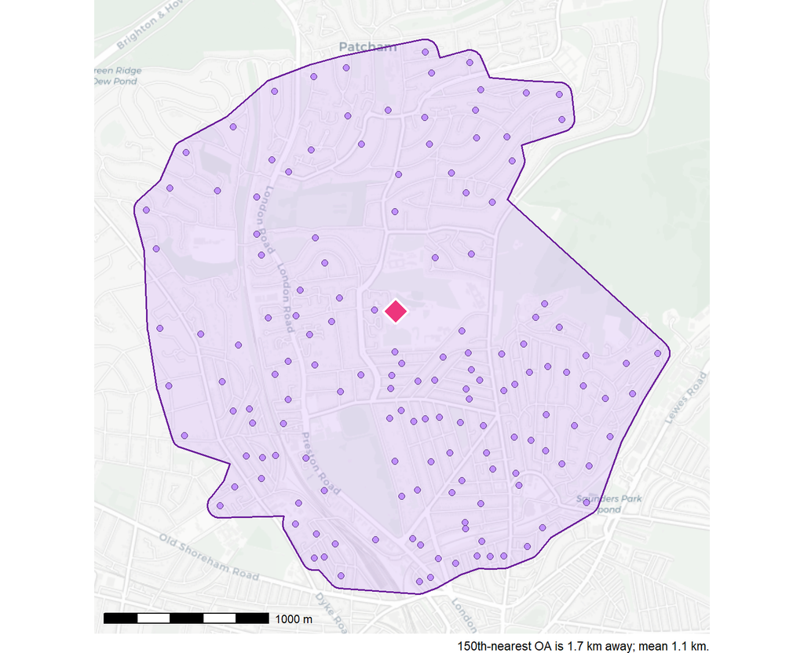

Figure 8: Dorothy Stringer School (pink diamond) and its 150 nearest Census Output Area population-weighted centroids (purple dots; shaded hull = their extent). This is the neighbourhood the k = 150 context variables average over — for a dense urban school, a compact ~1.5 km-radius patch. Basemap: CARTO / OpenStreetMap.

```r
library(sf)
library(ggspatial)

oa <- readRDS(here("data", "cache", "oa_pwc_2021.rds"))
ds <- panel %>%
  filter(grepl("Dorothy Stringer", SCHNAME)) %>%
  distinct(URN, SCHNAME, easting, northing) %>%
  slice(1)

# k = 150 nearest OA centroids (British National Grid), exactly as R/13 does it
nn <- nabor::knn(data  = as.matrix(oa[, c("easting", "northing")]),
                 query = as.matrix(ds[, c("easting", "northing")]),
                 k = 150)
oa150 <- oa[as.integer(nn$nn.idx[1, ]), ] %>%
  mutate(dist_km = nn$nn.dists[1, ] / 1000)

# to Web Mercator for the basemap tiles
oa_sf  <- st_as_sf(oa150, coords = c("easting", "northing"), crs = 27700) %>% st_transform(3857)
sch_sf <- st_as_sf(ds,    coords = c("easting", "northing"), crs = 27700) %>% st_transform(3857)
hull   <- concaveman::concaveman(oa_sf) %>% st_buffer(120)
bb     <- st_bbox(st_buffer(oa_sf, 500))

ggplot() +
  annotation_map_tile(type = "cartolight", zoom = 14, progress = "none") +
  geom_sf(data = hull, fill = "#993AFF", colour = "#6A1B9A", alpha = 0.12, linewidth = 0.6) +
  geom_sf(data = oa_sf, colour = "#3A1857", fill = "#B982FF", shape = 21,
          size = 2, stroke = 0.3, alpha = 0.85) +
  geom_sf(data = sch_sf, shape = 23, size = 6, stroke = 1.3, colour = "white", fill = "#ED357D") +
  annotation_scale(location = "bl", width_hint = 0.28) +
  coord_sf(xlim = c(bb["xmin"], bb["xmax"]), ylim = c(bb["ymin"], bb["ymax"]),
           crs = 3857, expand = FALSE) +
  labs(caption = sprintf("150th-nearest OA is %.1f km away; mean %.1f km.",
                         max(oa150$dist_km), mean(oa150$dist_km))) +
  theme_void()
```

For a dense urban school the 150-OA neighbourhood is a compact, genuinely *local* patch — the streets around the school, from Patcham down toward the city centre, not a generic regional average. This is why `k` is a **scale choice, not a nuisance**: the same 150 OAs around a rural school would sprawl over many kilometres, so the “right” `k` depends on how far a school actually draws its pupils. Secondaries, with their large catchments, prefer a much larger `k` than primaries (which favoured k = 10) — the AIC comparison below picks k = 150. The variables we average over each such neighbourhood are adult qualification (% with level 4+), unemployment and economic inactivity: a compact summary of the socio-educational fabric a school sits within.

## 15.2 Join and bivariate look

```r
ctx <- readRDS(here("data", "census", "school_census_context.rds"))

zs <- function(x) as.numeric(scale(x))

fd <- imputed_full_data %>%
  inner_join(
    ctx %>% select(URN, starts_with("cens_"), starts_with("mean_dist")),
    by = "URN"
  ) %>%
  mutate(
    z_l4plus_k10 = zs(cens_l4plus_k10),
    z_l4plus_k25 = zs(cens_l4plus_k25),
    z_l4plus_k50 = zs(cens_l4plus_k50),
    z_l4plus_k100 = zs(cens_l4plus_k100),
    z_l4plus_k150 = zs(cens_l4plus_k150),
    z_ltsick_k10 = zs(cens_ltsick_k10),
    z_ltsick_k25 = zs(cens_ltsick_k25),
    z_ltsick_k50 = zs(cens_ltsick_k50),
    z_ltsick_k100 = zs(cens_ltsick_k100),
    z_ltsick_k150 = zs(cens_ltsick_k150),
    z_unemp_k10  = zs(cens_unemp_k10),
    z_unemp_k25  = zs(cens_unemp_k25),
    z_unemp_k50  = zs(cens_unemp_k50),
    z_unemp_k100 = zs(cens_unemp_k100),
    z_unemp_k150 = zs(cens_unemp_k150),
    is_faith = !is.na(RELCHAR) &
      !RELCHAR %in% c("None", "Does not apply", "")
  )

cat("Analysis E sample:", nrow(imputed_full_data),
    "| joined to census context:", nrow(fd), "\n")
```

```
Analysis E sample: 12210 | joined to census context: 12210
```

```r
cat("Faith schools:", sum(fd$is_faith), "school-years (",
    round(100 * mean(fd$is_faith)), "% )\n")
```

```
Faith schools: 2202 school-years ( 18 % )
```

```r
tibble(
  k = c(10, 25, 50),
  `r(Att8, nbhd % level 4+)` = c(
    cor(fd$ATT8SCR, fd$cens_l4plus_k10, use = "pair"),
    cor(fd$ATT8SCR, fd$cens_l4plus_k25, use = "pair"),
    cor(fd$ATT8SCR, fd$cens_l4plus_k50, use = "pair")),
  `r(Att8, nbhd % no quals)` = c(
    cor(fd$ATT8SCR, fd$cens_noquals_k10, use = "pair"),
    cor(fd$ATT8SCR, fd$cens_noquals_k25, use = "pair"),
    cor(fd$ATT8SCR, fd$cens_noquals_k50, use = "pair")),
  `r(Att8, nbhd % unemployed)` = c(
    cor(fd$ATT8SCR, fd$cens_unemp_k10, use = "pair"),
    cor(fd$ATT8SCR, fd$cens_unemp_k25, use = "pair"),
    cor(fd$ATT8SCR, fd$cens_unemp_k50, use = "pair"))
) %>%
  mutate(across(-k, ~ round(., 2))) %>%
  knitr::kable(caption = "Bivariate correlations with Attainment 8 by neighbourhood size k")
```

Bivariate correlations with Attainment 8 by neighbourhood size k

| k | r(Att8, nbhd % level 4+) | r(Att8, nbhd % no quals) | r(Att8, nbhd % unemployed) |
| --- | --- | --- | --- |
| 10 | 0.44 | -0.36 | -0.09 |
| 25 | 0.44 | -0.38 | -0.09 |
| 50 | 0.43 | -0.37 | -0.08 |

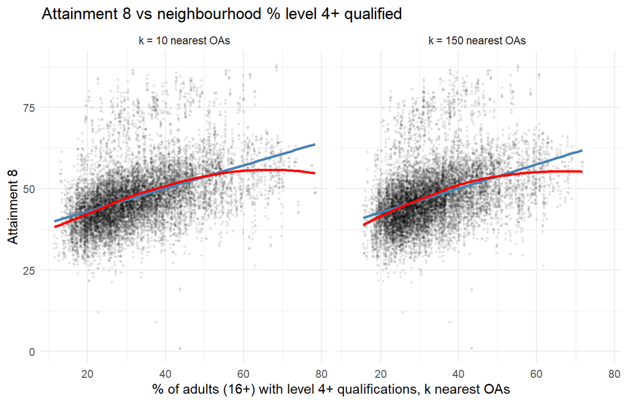

```r
fd %>%
  select(ATT8SCR, `k = 10 nearest OAs` = cens_l4plus_k10,
         `k = 150 nearest OAs` = cens_l4plus_k150) %>%
  pivot_longer(-ATT8SCR) %>%
  ggplot(aes(value, ATT8SCR)) +
  geom_point(alpha = 0.08, size = 0.5) +
  geom_smooth(method = "lm", se = FALSE, colour = "steelblue") +
  geom_smooth(method = "loess", se = FALSE, colour = "red") +
  facet_wrap(~name) +
  labs(title = "Attainment 8 vs neighbourhood % level 4+ qualified",
       x = "% of adults (16+) with level 4+ qualifications, k nearest OAs",
       y = "Attainment 8") +
  theme_minimal()
```

## 15.3 Does it survive prior attainment? And which k?

The Analysis E specification refitted (ML, identical joined sample) as the baseline, then census context added at each k.

```r
f_base_formula <- log(ATT8SCR) ~
  log(PTFSM6CLA1A) + log(PERCTOT) + log(PNUMEAL) +
  ks2_c + ADMPOL_PT + gorard_segregation +
  remained_in_the_same_school +
  teachers_on_leadership_pay_range_percent +
  log(average_number_of_days_taken) +
  (1 | year_label) + (1 | OFSTEDRATING_1) + (1 | gor_name/LANAME)

ctrl <- lmerControl(optimizer = "bobyqa", optCtrl = list(maxfun = 20000))

f_base <- lmer(f_base_formula, data = fd, REML = FALSE,
               na.action = na.exclude, control = ctrl)

add_census <- function(k) {
  update(f_base, as.formula(paste(
    ". ~ . +", paste0("z_l4plus_k", k), "+",
    paste0("z_ltsick_k", k), "+", paste0("z_unemp_k", k))))
}
f_k10  <- add_census(10)
f_k25  <- add_census(25)
f_k50  <- add_census(50)
f_k100 <- add_census(100)
f_k150 <- add_census(150)

map_dfr(list("E baseline (joined sample)" = f_base,
             "+ census, k = 10" = f_k10,
             "+ census, k = 25" = f_k25,
             "+ census, k = 50" = f_k50,
             "+ census, k = 100" = f_k100,
             "+ census, k = 150" = f_k150),
        function(m) {
          r <- suppressWarnings(performance::r2(m))
          tibble(`Marginal R²` = round(r$R2_marginal, 3),
                 `Conditional R²` = round(r$R2_conditional, 3),
                 AIC = round(AIC(m)), N = nobs(m))
        }, .id = "Model") %>%
  knitr::kable(caption = "Census context at KS4: contribution beyond the full Analysis E specification, by neighbourhood size. Secondary catchments are large: fit improves with k and is optimised (lowest AIC) around k = 150 (~2.5 km mean radius), well beyond the k = 10 that suits primary schools.")
```

Census context at KS4: contribution beyond the full Analysis E specification, by neighbourhood size. Secondary catchments are large: fit improves with k and is optimised (lowest AIC) around k = 150 (~2.5 km mean radius), well beyond the k = 10 that suits primary schools.

| Model | Marginal R² | Conditional R² | AIC | N |
| --- | --- | --- | --- | --- |
| E baseline (joined sample) | 0.661 | 0.776 | -23250 | 12199 |
| + census, k = 10 | 0.676 | 0.780 | -23419 | 12199 |
| + census, k = 25 | 0.679 | 0.781 | -23453 | 12199 |
| + census, k = 50 | 0.681 | 0.782 | -23478 | 12199 |
| + census, k = 100 | 0.683 | 0.783 | -23501 | 12199 |
| + census, k = 150 | 0.684 | 0.784 | -23513 | 12199 |

```r
best_k <- c("10" = AIC(f_k10), "25" = AIC(f_k25), "50" = AIC(f_k50),
            "100" = AIC(f_k100), "150" = AIC(f_k150))
best_k_name <- names(which.min(best_k))
f_best <- list("10" = f_k10, "25" = f_k25, "50" = f_k50,
               "100" = f_k100, "150" = f_k150)[[best_k_name]]
cat("Best-fitting neighbourhood size by AIC: k =", best_k_name, "\n\n")
```

```
Best-fitting neighbourhood size by AIC: k = 150
```

```r
s <- summary(f_best)$coefficients
as_tibble(s, rownames = "Term") %>%
  filter(Term != "(Intercept)") %>%
  mutate(across(where(is.numeric), ~ round(., 4))) %>%
  select(Term, Estimate, `Std. Error`, `t value`) %>%
  knitr::kable(caption = paste0("Full model + census context (k = ", best_k_name, ")"))
```

Full model + census context (k = 150)

| Term | Estimate | Std. Error | t value |
| --- | --- | --- | --- |
| log(PTFSM6CLA1A) | -0.0453 | 0.0029 | -15.7396 |
| log(PERCTOT) | -0.2052 | 0.0045 | -45.5572 |
| log(PNUMEAL) | 0.0024 | 0.0012 | 1.9680 |
| ks2_c | 0.0296 | 0.0007 | 44.5403 |
| ADMPOL_PTOTHER NON SEL | 0.0263 | 0.0066 | 4.0133 |
| ADMPOL_PTSEL | 0.0232 | 0.0075 | 3.1010 |
| gorard_segregation | 0.0303 | 0.0404 | 0.7490 |
| remained_in_the_same_school | 0.0005 | 0.0000 | 10.2229 |
| teachers_on_leadership_pay_range_percent | -0.0009 | 0.0002 | -4.5551 |
| log(average_number_of_days_taken) | -0.0125 | 0.0023 | -5.4570 |
| z_l4plus_k150 | 0.0217 | 0.0016 | 13.1863 |
| z_ltsick_k150 | -0.0027 | 0.0019 | -1.4057 |
| z_unemp_k150 | 0.0090 | 0.0016 | 5.6098 |

```r
comp <- bind_rows(
  as_tibble(summary(f_base)$coefficients, rownames = "Term") %>%
    mutate(Model = "E baseline"),
  as_tibble(summary(f_best)$coefficients, rownames = "Term") %>%
    mutate(Model = paste0("+ census (k=", best_k_name, ")"))
) %>%
  filter(Term %in% c("log(PTFSM6CLA1A)", "log(PERCTOT)", "ks2_c")) %>%
  select(Model, Term, Estimate) %>%
  pivot_wider(names_from = Model, values_from = Estimate) %>%
  mutate(across(where(is.numeric), ~ round(., 4)))
knitr::kable(comp, caption = "Do the core levers attenuate when neighbourhood context enters?")
```

Do the core levers attenuate when neighbourhood context enters?

| Term | E baseline | + census (k=150) |
| --- | --- | --- |
| log(PTFSM6CLA1A) | -0.0498 | -0.0453 |
| log(PERCTOT) | -0.2073 | -0.2052 |
| ks2_c | 0.0319 | 0.0296 |

## 15.4 The faith-school falsification check

```r
l4_var <- paste0("z_l4plus_k", best_k_name)
f_faith <- update(f_best, as.formula(paste(
  ". ~ . +", l4_var, ":is_faith + is_faith")))

sf <- summary(f_faith)$coefficients
as_tibble(sf, rownames = "Term") %>%
  filter(grepl("l4plus|faith", Term)) %>%
  mutate(across(where(is.numeric), ~ round(., 4))) %>%
  select(Term, Estimate, `Std. Error`, `t value`) %>%
  knitr::kable(caption = "Neighbourhood education effect x religious character (interaction model)")
```

Neighbourhood education effect x religious character (interaction model)

| Term | Estimate | Std. Error | t value |
| --- | --- | --- | --- |
| z_l4plus_k150 | 0.0222 | 0.0017 | 12.9690 |
| is_faithTRUE | 0.0032 | 0.0024 | 1.3398 |
| z_l4plus_k150:is_faithTRUE | -0.0023 | 0.0021 | -1.1075 |

If the interaction is negative — the census effect weaker where admission is faith-based rather than distance-based — the variable is doing what we claim: measuring the neighbourhoods schools actually serve. (A null here would caution that it proxies broader regional conditions instead.)

## 15.5 Variance components

```r
vc_tab <- function(m, label) {
  as.data.frame(VarCorr(m)) %>%
    filter(is.na(var2)) %>%
    transmute(Component = grp, !!label := round(vcov, 5))
}
left_join(vc_tab(f_base, "E baseline"),
          vc_tab(f_best, paste0("+ census (k=", best_k_name, ")")),
          by = "Component") %>%
  knitr::kable(caption = "Random-effect variance components before/after census context")
```

Random-effect variance components before/after census context

| Component | E baseline | + census (k=150) |
| --- | --- | --- |
| LANAME:gor_name | 0.00067 | 0.00046 |
| gor_name | 0.00019 | 0.00014 |
| OFSTEDRATING_1 | 0.00174 | 0.00157 |
| year_label | 0.00173 | 0.00164 |
| Residual | 0.00845 | 0.00829 |

## 15.6 How the LA league table changes when neighbourhoods enter

The caterpillar plot of LA random effects has served as an alternative LA ranking: how well a place does *after accounting for the measured factors*. Census context moves measurable neighbourhood conditions out of the random effect and into the model — so the caterpillar now answers a sharper question: **how well does an LA do after accounting for its schools’ cohorts *and* the educational character of its neighbourhoods?** Places whose high ranking rested on an educated populace should fall; places doing well *despite* weak neighbourhood human capital should rise.

```r
get_la_re <- function(m) {
  re <- ranef(m, condVar = TRUE)$`LANAME:gor_name`
  tibble(
    group = rownames(re),
    effect = re[["(Intercept)"]],
    se = sqrt(attr(re, "postVar")[1, 1, ]),
    la_name = sub(":.*$", "", group)
  )
}

la_cmp <- inner_join(
  get_la_re(f_base) %>% rename(effect_base = effect, se_base = se),
  get_la_re(f_best) %>% select(group, effect_census = effect, se_census = se),
  by = "group"
) %>%
  mutate(
    rank_base = rank(-effect_base),
    rank_census = rank(-effect_census),
    rank_shift = rank_base - rank_census   # positive = rises when census enters
  )

la_l4 <- fd %>%
  group_by(la_name = LANAME) %>%
  summarise(mean_l4plus = mean(cens_l4plus_k150, na.rm = TRUE), .groups = "drop")

la_cmp <- la_cmp %>% left_join(la_l4, by = "la_name")

bh <- la_cmp %>% filter(grepl("Brighton", la_name))
cat("Brighton and Hove: baseline effect", round(bh$effect_base, 4),
    "(rank", bh$rank_base, "of", nrow(la_cmp), ") ->",
    "with census", round(bh$effect_census, 4),
    "(rank", bh$rank_census, ")\n")
```

```
Brighton and Hove: baseline effect 0.0439 (rank 5 of 152 ) -> with census 0.0275 (rank 8 )
```

```r
cat("Correlation of LA effect *change* with LA mean % level 4+:",
    round(cor(la_cmp$effect_census - la_cmp$effect_base,
              la_cmp$mean_l4plus, use = "pair"), 2), "\n")
```

```
Correlation of LA effect *change* with LA mean % level 4+: -0.69
```

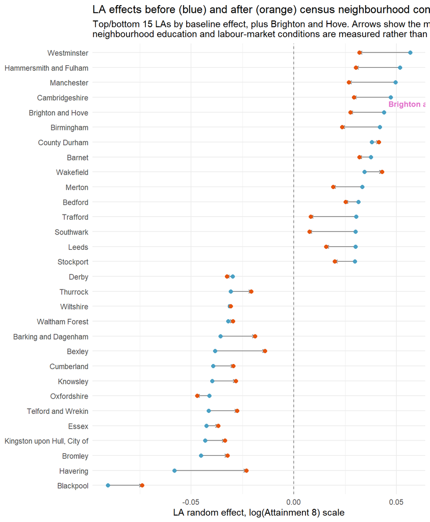

```r
show_las <- la_cmp %>%
  arrange(effect_base) %>%
  slice(c(1:15, (n() - 14):n())) %>%
  bind_rows(bh) %>%
  distinct(group, .keep_all = TRUE)

ggplot(show_las, aes(y = reorder(la_name, effect_base))) +
  geom_vline(xintercept = 0, linetype = "dashed", colour = "grey50") +
  geom_segment(aes(x = effect_base, xend = effect_census, yend = la_name),
               arrow = arrow(length = unit(0.13, "cm")), colour = "grey45") +
  geom_point(aes(x = effect_base), colour = "#49a0c4", size = 2) +
  geom_point(aes(x = effect_census), colour = "#e6550d", size = 2) +
  geom_text(data = show_las %>% filter(grepl("Brighton", la_name)),
            aes(x = effect_base, label = "  Brighton and Hove"),
            hjust = 0, vjust = -1, colour = "#e16fca", fontface = "bold", size = 3.2) +
  labs(title = "LA effects before (blue) and after (orange) census neighbourhood context",
       subtitle = "Top/bottom 15 LAs by baseline effect, plus Brighton and Hove. Arrows show the movement when\nneighbourhood education and labour-market conditions are measured rather than absorbed.",
       x = "LA random effect, log(Attainment 8) scale", y = NULL) +
  theme_minimal()
```

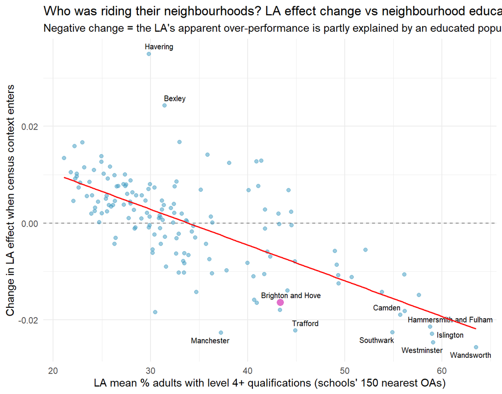

```r
ggplot(la_cmp, aes(mean_l4plus, effect_census - effect_base)) +
  geom_hline(yintercept = 0, linetype = "dashed", colour = "grey50") +
  geom_point(alpha = 0.55, size = 1.6, colour = "#49a0c4") +
  geom_point(data = bh, colour = "#e16fca", size = 3) +
  ggrepel::geom_text_repel(
    data = la_cmp %>%
      filter(rank(-abs(effect_census - effect_base)) <= 10 | grepl("Brighton", la_name)),
    aes(label = la_name), size = 2.7, max.overlaps = 20) +
  geom_smooth(method = "lm", se = FALSE, colour = "red", linewidth = 0.7) +
  labs(title = "Who was riding their neighbourhoods? LA effect change vs neighbourhood education",
       subtitle = "Negative change = the LA's apparent over-performance is partly explained by an educated populace",
       x = "LA mean % adults with level 4+ qualifications (schools' 150 nearest OAs)",
       y = "Change in LA effect when census context enters") +
  theme_minimal()
```

```r
bind_rows(
  la_cmp %>% slice_max(rank_shift, n = 8) %>% mutate(Direction = "Risers (better than their neighbourhoods suggested)"),
  la_cmp %>% slice_min(rank_shift, n = 8) %>% mutate(Direction = "Fallers (ranking partly reflected educated neighbourhoods)"),
  bh %>% mutate(Direction = "Brighton and Hove")
) %>%
  transmute(Direction, LA = la_name,
            `Mean % L4+` = round(mean_l4plus, 1),
            `Rank (baseline)` = rank_base,
            `Rank (with census)` = rank_census,
            `Shift` = rank_shift) %>%
  knitr::kable(caption = "Largest ranking movements when neighbourhood context is measured (rank 1 = best; positive shift = rises)")
```

Largest ranking movements when neighbourhood context is measured (rank 1 = best; positive shift = rises)

| Direction | LA | Mean % L4+ | Rank (baseline) | Rank (with census) | Shift |
| --- | --- | --- | --- | --- | --- |
| Risers (better than their neighbourhoods suggested) | Sutton | 40.9 | 71 | 27 | 44 |
| Risers (better than their neighbourhoods suggested) | North Northamptonshire | 24.9 | 77 | 35 | 42 |
| Risers (better than their neighbourhoods suggested) | Rotherham | 21.8 | 87 | 48 | 39 |
| Risers (better than their neighbourhoods suggested) | North Lincolnshire | 22.3 | 89 | 54 | 35 |
| Risers (better than their neighbourhoods suggested) | Peterborough | 25.6 | 90 | 55 | 35 |
| Risers (better than their neighbourhoods suggested) | Tameside | 24.2 | 64 | 29 | 35 |
| Risers (better than their neighbourhoods suggested) | Doncaster | 22.4 | 49 | 18 | 31 |
| Risers (better than their neighbourhoods suggested) | Halton | 22.6 | 75 | 45 | 30 |
| Fallers (ranking partly reflected educated neighbourhoods) | Islington | 58.9 | 33 | 100 | -67 |
| Fallers (ranking partly reflected educated neighbourhoods) | Wandsworth | 63.5 | 21 | 83 | -62 |
| Fallers (ranking partly reflected educated neighbourhoods) | Camden | 55.7 | 36 | 92 | -56 |
| Fallers (ranking partly reflected educated neighbourhoods) | York | 40.7 | 28 | 69 | -41 |
| Fallers (ranking partly reflected educated neighbourhoods) | Reading | 41.7 | 57 | 97 | -40 |
| Fallers (ranking partly reflected educated neighbourhoods) | Kensington and Chelsea | 57.6 | 30 | 68 | -38 |
| Fallers (ranking partly reflected educated neighbourhoods) | Southwark | 54.9 | 13 | 50 | -37 |
| Fallers (ranking partly reflected educated neighbourhoods) | Trafford | 44.9 | 12 | 49 | -37 |
| Brighton and Hove | Brighton and Hove | 43.4 | 5 | 8 | -3 |

## 15.7 How big is the school effect, really?

The B&H policy debate assumes moving pupils between schools changes outcomes — implicitly, that *which school you attend* carries a large effect relative to *who you are and where you live*. The panel lets us bound this. Adding a school-level random intercept to the census model decomposes the unexplained variance into a **persistent school component** (the same school doing better/worse than expected, year after year) and **transient cohort noise**.

We also split the **fixed-effects** share into two conceptually distinct groups, because the single combined figure conflates things a school inherits with things a school does:

- **Exogenous, non-school** — the hand the school is dealt: cohort composition (disadvantage, EAL), prior attainment at intake, absence, admissions/segregation structure and neighbourhood context. A school cannot choose these.
- **Endogenous, within-school** — the workforce levers the school actually controls: teacher retention, leadership pay share, and teacher sickness.

The split uses an exact additive variance decomposition: each group’s contribution is the covariance of its linear-predictor component with the full fixed-effect predictor, so the two contributions (including their shared covariance) sum precisely to the total fixed-effect variance.

```r
# Endogenous (school-controllable) fixed effects = workforce terms.
# Everything else in the fixed part is exogenous to the school's own practice.
workforce_terms <- c("remained_in_the_same_school",
                     "teachers_on_leadership_pay_range_percent",
                     "log(average_number_of_days_taken)")

# Exact additive split of the fixed-effect variance into two groups via
# covariance-with-total: cov(eta_g, eta_full) sums over groups to var(eta_full).
split_fixed_var <- function(m, endo_terms = workforce_terms) {
  X    <- getME(m, "X")
  beta <- fixef(m)
  cn   <- colnames(X)
  is_int  <- cn == "(Intercept)"
  is_endo <- cn %in% endo_terms
  eta_endo <- as.vector(X[, is_endo, drop = FALSE] %*% beta[is_endo])
  eta_exo  <- as.vector(X[, !is_endo & !is_int, drop = FALSE] %*%
                          beta[!is_endo & !is_int])
  eta_full <- eta_exo + eta_endo
  c(exo = cov(eta_exo, eta_full), endo = cov(eta_endo, eta_full))
}

f_school <- update(f_best, . ~ . + (1 | URN))

vc <- as.data.frame(VarCorr(f_school)) %>% filter(is.na(var2))
fx <- split_fixed_var(f_school)
fixed_var <- sum(fx)
total_var <- fixed_var + sum(vc$vcov)

decomp <- vc %>%
  transmute(Component = recode(grp,
    "URN" = "School (persistent, unexplained)",
    "LANAME:gor_name" = "LA (within region)",
    "gor_name" = "Region",
    "OFSTEDRATING_1" = "Ofsted rating",
    "year_label" = "Year",
    "Residual" = "Transient (cohort-year noise)"),
    Variance = vcov) %>%
  bind_rows(tibble(
    Component = c("Exogenous, non-school (cohort, prior attainment, absence, neighbourhood)",
                  "Endogenous, within-school (workforce)"),
    Variance = c(fx[["exo"]], fx[["endo"]]))) %>%
  mutate(`Share of total %` = round(100 * Variance / total_var, 1),
         `SD (log Att8)` = round(sqrt(pmax(Variance, 0)), 4),
         `~Attainment 8 points (at mean 46)` = round(46 * sqrt(pmax(Variance, 0)), 1)) %>%
  arrange(desc(Variance))

knitr::kable(decomp %>% select(-Variance),
             caption = "Variance decomposition of log(Attainment 8), census model + school random intercept (fixed effects split into exogenous non-school vs endogenous within-school workforce)")
```

Variance decomposition of log(Attainment 8), census model + school random intercept (fixed effects split into exogenous non-school vs endogenous within-school workforce)

| Component | Share of total % | SD (log Att8) | ~Attainment 8 points (at mean 46) |
| --- | --- | --- | --- |
| Exogenous, non-school (cohort, prior attainment, absence, neighbourhood) | 64.9 | 0.1543 | 7.1 |
| School (persistent, unexplained) | 14.7 | 0.0733 | 3.4 |
| Transient (cohort-year noise) | 8.9 | 0.0572 | 2.6 |
| Year | 4.1 | 0.0388 | 1.8 |
| Ofsted rating | 3.5 | 0.0358 | 1.6 |
| Endogenous, within-school (workforce) | 2.8 | 0.0319 | 1.5 |
| LA (within region) | 0.8 | 0.0170 | 0.8 |
| Region | 0.4 | 0.0121 | 0.6 |

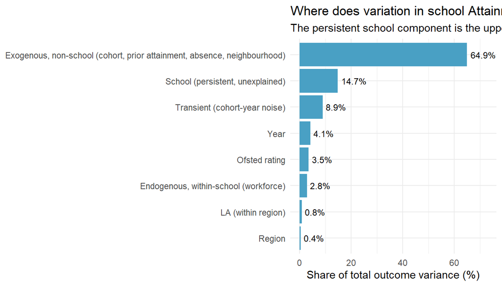

```r
decomp %>%
  mutate(Component = fct_reorder(Component, `Share of total %`)) %>%
  ggplot(aes(`Share of total %`, Component)) +
  geom_col(fill = "#49a0c4") +
  geom_text(aes(label = paste0(`Share of total %`, "%")), hjust = -0.15, size = 3.2) +
  xlim(0, max(decomp$`Share of total %`) * 1.12) +
  labs(title = "Where does variation in school Attainment 8 come from?",
       subtitle = "The persistent school component is the upper bound on what changing schools could achieve, holding the child constant",
       x = "Share of total outcome variance (%)", y = NULL) +
  theme_minimal()
```

Two readings of the school component, and both matter for the B&H debate:

- It is an **upper bound** on the causal effect of school membership: the URN intercept absorbs everything persistently school-specific that the model cannot see — genuinely better teaching and leadership, but also stable unmeasured intake sorting (the sought-after school’s catchment premium). The true “what the school adds” effect is *at most* this large.
- Even taken at face value, compare its magnitude with the **exogenous, non-school** share: the hand a school is dealt — its cohort’s composition, prior attainment, attendance and neighbourhood context — dwarfs both the school’s own persistent departure from expectation *and* the endogenous, within-school (workforce) fixed effects the school actually controls. Splitting the fixed part makes this explicit: the school-controllable workforce component is a small slice, while the inherited exogenous component does almost all the work. Reallocating pupils between schools redistributes *which building children sit in* but changes neither their prior attainment, their home neighbourhoods, nor (directly) their attendance. The plausible attainment gain from moving a child to a school one standard deviation “better” is a few Attainment 8 points at most, and that is before netting out the catchment-sorting component of the school effect.

### 15.7.1 The same decomposition for disadvantaged pupils

The B&H reallocation debate is specifically about *disadvantaged* attainment, so the decomposition that matters most uses the disadvantaged-pupil outcome:

```r
fd_dis <- fd %>%
  filter(!is.na(ATT8SCR_FSM6CLA1A), ATT8SCR_FSM6CLA1A > 0) %>%
  droplevels()
contrasts(fd_dis$OFSTEDRATING_1) <- contr.treatment(levels(fd_dis$OFSTEDRATING_1))

f_dis_base <- lmer(
  log(ATT8SCR_FSM6CLA1A) ~
    log(PTFSM6CLA1A) + log(PERCTOT) + log(PNUMEAL) +
    ks2_c + ADMPOL_PT + gorard_segregation +
    remained_in_the_same_school +
    teachers_on_leadership_pay_range_percent +
    log(average_number_of_days_taken) +
    (1 | year_label) + (1 | OFSTEDRATING_1) + (1 | gor_name/LANAME),
  data = fd_dis, REML = FALSE, na.action = na.exclude, control = ctrl)

f_dis_census <- update(f_dis_base, . ~ . + z_l4plus_k150 + z_ltsick_k150 + z_unemp_k150)
f_dis_school <- update(f_dis_census, . ~ . + (1 | URN))

mean_att8_dis <- mean(fd_dis$ATT8SCR_FSM6CLA1A, na.rm = TRUE)

decompose_model <- function(m, att8_mean) {
  vc <- as.data.frame(VarCorr(m)) %>% filter(is.na(var2))
  fx <- split_fixed_var(m)
  fixed_var <- sum(fx)
  total_var <- fixed_var + sum(vc$vcov)
  vc %>%
    transmute(Component = recode(grp,
      "URN" = "School (persistent, unexplained)",
      "LANAME:gor_name" = "LA (within region)",
      "gor_name" = "Region",
      "OFSTEDRATING_1" = "Ofsted rating",
      "year_label" = "Year",
      "Residual" = "Transient (cohort-year noise)"),
      Variance = vcov) %>%
    bind_rows(tibble(
      Component = c("Exogenous, non-school (cohort, prior attainment, absence, neighbourhood)",
                    "Endogenous, within-school (workforce)"),
      Variance = c(fx[["exo"]], fx[["endo"]]))) %>%
    mutate(`Share of total %` = round(100 * Variance / total_var, 1),
           `SD (log Att8)` = round(sqrt(pmax(Variance, 0)), 4),
           `~Attainment 8 points` = round(att8_mean * sqrt(pmax(Variance, 0)), 1)) %>%
    arrange(desc(Variance))
}

decomp_dis <- decompose_model(f_dis_school, mean_att8_dis)

knitr::kable(decomp_dis %>% select(-Variance),
             caption = sprintf("Variance decomposition, disadvantaged pupils' log(Attainment 8) (N = %s; mean disadvantaged Att8 = %.1f)",
                               format(nobs(f_dis_school), big.mark = ","), mean_att8_dis))
```

Variance decomposition, disadvantaged pupils’ log(Attainment 8) (N = 12,060; mean disadvantaged Att8 = 38.5)

| Component | Share of total % | SD (log Att8) | ~Attainment 8 points |
| --- | --- | --- | --- |
| Exogenous, non-school (cohort, prior attainment, absence, neighbourhood) | 57.8 | 0.1667 | 6.4 |
| Transient (cohort-year noise) | 18.1 | 0.0932 | 3.6 |
| School (persistent, unexplained) | 10.2 | 0.0701 | 2.7 |
| Year | 5.9 | 0.0531 | 2.0 |
| Ofsted rating | 4.3 | 0.0455 | 1.8 |
| LA (within region) | 1.8 | 0.0292 | 1.1 |
| Region | 1.0 | 0.0224 | 0.9 |
| Endogenous, within-school (workforce) | 0.8 | 0.0201 | 0.8 |

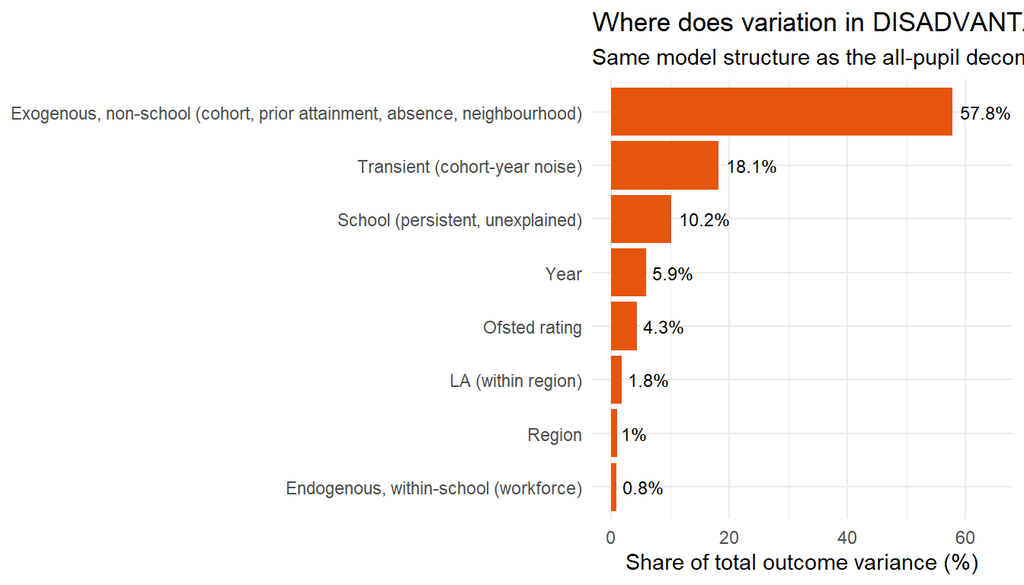

```r
decomp_dis %>%
  mutate(Component = fct_reorder(Component, `Share of total %`)) %>%
  ggplot(aes(`Share of total %`, Component)) +
  geom_col(fill = "#e6550d") +
  geom_text(aes(label = paste0(`Share of total %`, "%")), hjust = -0.15, size = 3.2) +
  xlim(0, max(decomp_dis$`Share of total %`) * 1.12) +
  labs(title = "Where does variation in DISADVANTAGED pupils' Attainment 8 come from?",
       subtitle = "Same model structure as the all-pupil decomposition above",
       x = "Share of total outcome variance (%)", y = NULL) +
  theme_minimal()
```

```r
la_cmp_dis <- inner_join(
  get_la_re(f_dis_base) %>% rename(effect_base = effect, se_base = se),
  get_la_re(f_dis_census) %>% select(group, effect_census = effect, se_census = se),
  by = "group") %>%
  mutate(rank_base = rank(-effect_base), rank_census = rank(-effect_census),
         rank_shift = rank_base - rank_census) %>%
  left_join(la_l4, by = "la_name")

bh_dis <- la_cmp_dis %>% filter(grepl("Brighton", la_name))
cat("Disadvantaged pupils — Brighton and Hove: baseline effect",
    round(bh_dis$effect_base, 4), "(rank", bh_dis$rank_base, ") -> with census",
    round(bh_dis$effect_census, 4), "(rank", bh_dis$rank_census, ")\n")
```

```
Disadvantaged pupils — Brighton and Hove: baseline effect 0.0406 (rank 15 ) -> with census 0.0343 (rank 17 )
```

```r
# Cache headline Analysis F objects for reuse (e.g. slide decks) without refits
saveRDS(list(
  decomp_all = decomp, decomp_dis = decomp_dis,
  la_cmp = la_cmp, la_cmp_dis = la_cmp_dis,
  bh_all = la_cmp %>% filter(grepl("Brighton", la_name)),
  bh_dis = bh_dis,
  mean_att8_all = 46, mean_att8_dis = mean_att8_dis,
  r2 = list(base_marginal = performance::r2(f_base)$R2_marginal,
            census_marginal = performance::r2(f_best)$R2_marginal),
  best_k = best_k_name,
  cor_shift_l4 = cor(la_cmp$effect_census - la_cmp$effect_base,
                     la_cmp$mean_l4plus, use = "pair")
), here("data", "cache", "analysis_f_results.rds"))
cat("Saved data/cache/analysis_f_results.rds\n")
```

```
Saved data/cache/analysis_f_results.rds
```

The disadvantaged decomposition (compare shares with the all-pupil table above, computed live in both cases) carries the same structural message: the dominant share of variation is the hand the school is dealt; the persistent school component is real but secondary; and small disadvantaged cohorts make the transient share larger than for all pupils — single-year disadvantaged league tables are noisier still.

## 15.8 What the decomposition means for a pupil

The variance shares above are the natural output of the model, but they invite two misreadings, so three presentation views (developed for the slide deck and reproduced here with fuller workings) make the substance concrete. All are built from the two decompositions already computed — `decomp` for all pupils and `decomp_dis` for disadvantaged pupils — so nothing is refitted. First we collapse the eight components into three plain-English buckets:

- **Inherited — the hand the school is dealt:** the *exogenous* fixed effects — cohort disadvantage and EAL, prior attainment, absence, neighbourhood context, plus admissions type and segregation. Things the school cannot choose.
- **What the school adds:** the *persistent between-school effect* (the URN random intercept) plus the *school-controllable workforce* fixed effects — leadership pay, teacher retention, sickness. Genuine school quality *and*, in the persistent term, any stable unmeasured intake sorting — which is why it is an upper bound.
- **Area, year & luck:** region, LA, Ofsted rating, year, and transient cohort-year noise.

### 15.8.1 View 1 — what a school’s average Attainment 8 is “made of”

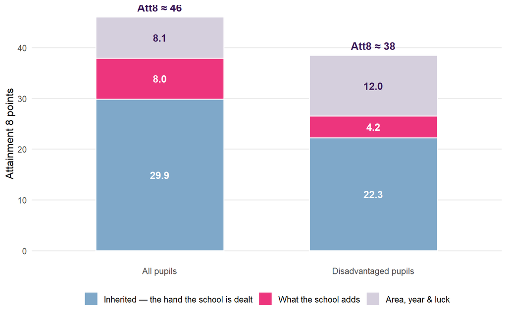

Figure 9: Schematic breakdown of school-average Attainment 8 for all pupils and disadvantaged pupils. Bar height is each group’s mean score; each block is that factor’s share of the between-school variance, scaled to the mean.

```r
ggplot(.buck, aes(who, pts, fill = grp)) +
  geom_col(width = 0.6, colour = "white", linewidth = 0.6) +
  geom_text(aes(label = sprintf("%.1f", pts), colour = lab_col),
            position = position_stack(vjust = 0.5), fontface = "bold", size = 4) +
  scale_colour_identity() +
  geom_text(data = .tot, aes(x = who, y = total, label = sprintf("Att8 ≈ %.0f", total)),
            inherit.aes = FALSE, vjust = -0.7, fontface = "bold", colour = "#3A1857") +
  scale_fill_manual(values = .bpal, name = NULL, breaks = .blvl) +
  labs(x = NULL, y = "Attainment 8 points") +
  theme_minimal(base_size = 12) +
  theme(legend.position = "bottom", panel.grid.major.x = element_blank(),
        panel.grid.minor = element_blank())
```

### 15.8.2 View 2 — the fixed part, split into inherited vs school-controllable

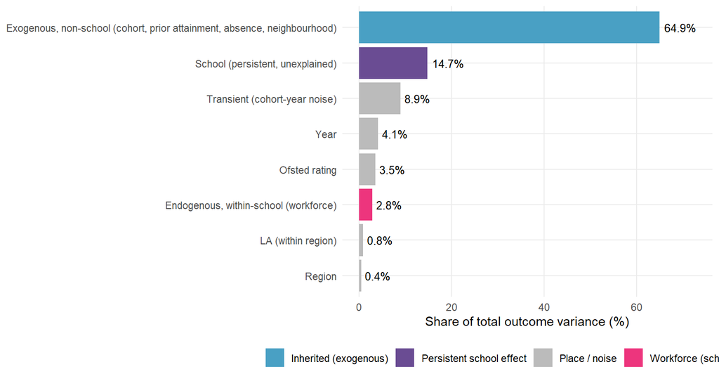

Figure 10: The full all-pupil variance decomposition, coloured by whether a component is inherited (exogenous), the school’s own persistent effect, the school-controllable workforce inputs, or place/noise. The exact exogenous/endogenous split uses covariance-with-total, so the two fixed groups sum to the fixed-effect variance.

```r
decomp %>%
  mutate(grp = case_when(
    grepl("^Exogenous", Component)  ~ "Inherited (exogenous)",
    grepl("^Endogenous", Component) ~ "Workforce (school-controllable)",
    Component == "School (persistent, unexplained)" ~ "Persistent school effect",
    TRUE ~ "Place / noise"),
    Component = fct_reorder(Component, `Share of total %`)) %>%
  ggplot(aes(`Share of total %`, Component, fill = grp)) +
  geom_col() +
  geom_text(aes(label = paste0(`Share of total %`, "%")), hjust = -0.15, size = 3.4) +
  scale_fill_manual(values = c("Inherited (exogenous)" = "#49a0c4",
                               "Persistent school effect" = "#6A4C93",
                               "Workforce (school-controllable)" = "#ED357D",
                               "Place / noise" = "#BBBBBB"), name = NULL) +
  xlim(0, max(decomp$`Share of total %`) * 1.12) +
  labs(x = "Share of total outcome variance (%)", y = NULL) +
  theme_minimal(base_size = 11) +
  theme(legend.position = "bottom", panel.grid.minor = element_blank())
```

### 15.8.3 View 3 — what a *better* school adds, and how far it closes the gap

Views 1–2 answer “what *shares* the variation”. A different, cleaner question is “what does attending a *better* school actually add to a pupil?” — and the answer is the **standard deviation** of the persistent school effect, not its variance share. The two are easily confused. From `decomp_dis`, the persistent school component has an SD on the log scale that, at the disadvantaged mean, converts to Attainment 8 points as follows:

```r
.sd_log_dis <- decomp_dis$`SD (log Att8)`[decomp_dis$Component == "School (persistent, unexplained)"]
.sd_pts_dis <- mean_att8_dis * .sd_log_dis
.baca_va    <- quadrant_data_disadv$vadd_M2_disadv[grepl("Brighton Aldridge", quadrant_data_disadv$SCHNAME)]
cat(sprintf("Persistent school SD (disadvantaged): %.4f on log scale = %.2f Attainment 8 points per SD\n",
            .sd_log_dis, .sd_pts_dis))
```

```
Persistent school SD (disadvantaged): 0.0701 on log scale = 2.70 Attainment 8 points per SD
```

```r
cat(sprintf("Disadvantage gap: all-pupil mean 46 vs disadvantaged mean %.1f = %.1f Att8 points\n",
            mean_att8_dis, 46 - mean_att8_dis))
```

```
Disadvantage gap: all-pupil mean 46 vs disadvantaged mean 38.5 = 7.5 Att8 points
```

```r
cat(sprintf("BACA two-stage disadvantaged value-added: %+.1f Att8 points (%.1f SD above the typical school)\n",
            .baca_va, .baca_va / .sd_pts_dis))
```

```
BACA two-stage disadvantaged value-added: +2.6 Att8 points (1.0 SD above the typical school)
```

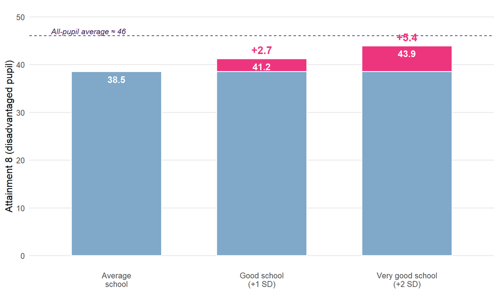

Figure 11: The persistent school effect is additive. A disadvantaged pupil’s expected Attainment 8 at an average, good (+1 SD) and very good (+2 SD) school; the pink block is what the school adds on top of the pupil’s inherited baseline. Dashed line = the all-pupil average.

```r
.bd <- tibble(
  who = factor(c("Average\nschool", "Good school\n(+1 SD)", "Very good school\n(+2 SD)"),
               levels = c("Average\nschool", "Good school\n(+1 SD)", "Very good school\n(+2 SD)")),
  base = mean_att8_dis, boost = c(0, .sd_pts_dis, 2 * .sd_pts_dis)) %>%
  pivot_longer(c(base, boost), names_to = "part", values_to = "pts") %>%
  mutate(part = factor(part, levels = c("boost", "base")))
.lab <- .bd %>% group_by(who) %>% summarise(total = sum(pts), boost = pts[part == "boost"], .groups = "drop")

ggplot(.bd, aes(who, pts, fill = part)) +
  geom_col(width = 0.62, colour = "white", linewidth = 0.6) +
  geom_hline(yintercept = 46, linetype = "dashed", colour = "#3A1857", linewidth = 0.5) +
  annotate("text", x = 0.55, y = 47, label = "All-pupil average ≈ 46", hjust = 0,
           size = 3.3, colour = "#3A1857", fontface = "italic") +
  geom_text(data = .lab %>% filter(boost > 0), aes(x = who, y = total, label = sprintf("+%.1f", boost)),
            inherit.aes = FALSE, vjust = -0.6, fontface = "bold", colour = "#ED357D", size = 4.6) +
  geom_text(data = .lab, aes(x = who, y = total, label = sprintf("%.1f", total)),
            inherit.aes = FALSE, vjust = 1.6, fontface = "bold", colour = "white", size = 4) +
  scale_fill_manual(values = c(base = "#7FA8C9", boost = "#ED357D"), guide = "none") +
  coord_cartesian(ylim = c(0, 50)) +
  labs(x = NULL, y = "Attainment 8 (disadvantaged pupil)") +
  theme_minimal(base_size = 12) +
  theme(panel.grid.major.x = element_blank(), panel.grid.minor = element_blank())
```

**The two numbers are not the same thing.** View 1’s “what the school adds” block (a share of variance, scaled by the mean) and View 3’s per-SD boost answer *different* questions — *how much do schools differ* versus *what does moving between them do to a pupil*. The variance share can look modest while the per-SD effect is large; conflating them is the single easiest way to misread this analysis.

## 15.9 Reading Analysis F

Interpretation notes (mirroring the KS2 Phase F lessons):

- **The decisive comparison is against the full Analysis E baseline** — prior attainment, disadvantage, EAL, absence, workforce, Ofsted, admissions policy and segregation are all already in. Any census contribution here is *net* of the school’s own measured intake.
- **k-sensitivity is informative, not nuisance**: larger k fits better at KS4 (optimum k ≈ 150, ~2.5 km) than the k = 10 that suits primaries — the catchment-scale geography showing through in the data, consistent with the spatial programme’s premise.
- **The faith interaction is the validity probe**: distance-defined context should matter most where admission is distance-defined.
- The LA/region variance movement shows how much of the *remaining* place effect (after Analysis E’s rich controls) is measurable neighbourhood conditions — the KS4 counterpart of the KS2 finding that census context explained ~two-thirds of the between-LA variance.

# 16 Reviewer-response diagnostics

This section collects the supplementary analyses referenced from the main paper’s revision: the prior-attainment robustness check (mean KS2 score), the Ofsted specification comparison (random effect versus fixed effect), and the functional-form diagnostics (which predictors are log-transformed, and why). All use the same Analysis E estimation data as the headline models.

## 16.1 Prior-attainment measure: why mean KS2 rather than the low-attainer share

The models control for prior attainment using the cohort’s **mean KS2 scaled score** (`ks2_c`, centred at the national standard of 100). An earlier version of this work used the *percentage of pupils with low KS2 prior attainment* (`PTPRIORLO`) instead. This section documents why the measure was changed, and what changing it does.

Two preliminaries. First, **no** prior-attainment measure is observed for 2024-25: the KS2 tests and assessments of 2019-20 and 2020-21 were cancelled during the pandemic, so the cohorts reaching the end of KS4 in 2024-25 and 2025-26 have no KS2 results, and the DfE publishes neither prior-attainment measures nor Progress 8 for those years. In the raw 2024-25 performance-table file, `KS2ASS`, `PTPRIORLO`, `PTPRIORAV` and `PTPRIORHI` are all `NA` for every school. Second, and consequently, *whichever* measure is used must be carry-forward imputed for that year. Both are imputable on identical terms (`04_compute_derived.R` imputes 3,221 rows for `KS2ASS` and 3,222 for `PTPRIORLO`), so data availability was never a reason to prefer one over the other, and the affected rows are flagged by `has_imputed_predictors`.

The substantive reason for preferring mean KS2 is that the low-attainer share observes only one tail of the intake distribution. It records how many pupils arrived already behind, but is silent on how many arrived ahead. Two schools with the same proportion of low prior attainers can differ substantially in the size of their upper tail, and a model controlling only for the low-attainer share cannot tell them apart — so it under-adjusts for schools whose intake advantage sits at the top. The comparison below refits the full model on the whole panel under three specifications.

```r
fit_pa <- function(prior_term) {
  rest <- sub("ks2_c \\+ ", "", rd_rhs)   # strip the default prior term
  lmer(as.formula(paste0("log(ATT8SCR) ~ ", prior_term, " + ", rest,
                          " + ", rd_ranef)),
       data = rd_data, REML = FALSE, control = ctrl_rd)
}

pa_specs <- list("L: low-attainer share only" = "PTPRIORLO",
                 "M: mean KS2 only (used here)" = "ks2_c",
                 "B: both" = "PTPRIORLO + ks2_c")

pa_tab <- purrr::map_dfr(names(pa_specs), function(nm) {
  m <- fit_pa(pa_specs[[nm]])
  s <- summary(m)$coefficients
  tibble(Specification = nm,
         log_FSM = s["log(PTFSM6CLA1A)", "Estimate"],
         log_Absence = s["log(PERCTOT)", "Estimate"],
         marginal_R2 = as.numeric(performance::r2(m)$R2_marginal),
         AIC = AIC(m))
}) %>% mutate(dAIC = AIC - min(AIC))

knitr::kable(pa_tab, digits = c(0, 4, 4, 3, 0, 1),
             caption = "All-pupil model under three prior-attainment specifications (ML fits, for AIC comparability). Mean KS2 fits substantially better; adding the low-attainer share on top buys nothing.")
```

All-pupil model under three prior-attainment specifications (ML fits, for AIC comparability). Mean KS2 fits substantially better; adding the low-attainer share on top buys nothing.

| Specification | log_FSM | log_Absence | marginal_R2 | AIC | dAIC |
| --- | --- | --- | --- | --- | --- |
| L: low-attainer share only | -0.0675 | -0.2132 | 0.642 | -22717 | 533.2 |
| M: mean KS2 only (used here) | -0.0498 | -0.2073 | 0.661 | -23250 | 0.0 |
| B: both | -0.0499 | -0.2072 | 0.661 | -23248 | 1.8 |

```r
.L <- pa_tab[grepl("^L:", pa_tab$Specification), ]
.M <- pa_tab[grepl("^M:", pa_tab$Specification), ]
.abs_chg <- 100 * (.M$log_Absence - .L$log_Absence) / abs(.L$log_Absence)
.fsm_chg <- 100 * (.M$log_FSM - .L$log_FSM) / abs(.L$log_FSM)
.both <- fit_pa("PTPRIORLO + ks2_c")
.t_lo <- summary(.both)$coefficients["PTPRIORLO", "t value"]

cat(sprintf(
"Mean KS2 improves AIC by %.0f relative to the low-attainer share, and when both are entered together the low-attainer share is indistinguishable from zero (*t* = %.2f) --- mean KS2 fully absorbs it.\n\nSwitching measure moves the **absence** coefficient by only %.1f%%, so the central finding of the paper is unaffected by the choice. The **disadvantage-concentration** coefficient, however, changes by %.0f%%: the low-attainer share had left part of the intake difference between high- and low-FSM schools unmeasured, and the FSM term had been absorbing it. Properly controlled, disadvantage concentration is a weaker predictor still.\n",
  .L$AIC - .M$AIC, .t_lo, .abs_chg, .fsm_chg))
```

Mean KS2 improves AIC by 533 relative to the low-attainer share, and when both are entered together the low-attainer share is indistinguishable from zero (*t* = -0.47) — mean KS2 fully absorbs it.

Switching measure moves the **absence** coefficient by only 2.8%, so the central finding of the paper is unaffected by the choice. The **disadvantage-concentration** coefficient, however, changes by 26%: the low-attainer share had left part of the intake difference between high- and low-FSM schools unmeasured, and the FSM term had been absorbing it. Properly controlled, disadvantage concentration is a weaker predictor still.

```r
fit_pa_dis <- function(prior_term) {
  rest <- sub("ks2_c \\+ ", "", rd_rhs)
  lmer(as.formula(paste0("log(ATT8SCR_FSM6CLA1A) ~ ", prior_term, " + ", rest,
                          " + ", rd_ranef)),
       data = rd_data %>% filter(!is.na(ATT8SCR_FSM6CLA1A), ATT8SCR_FSM6CLA1A > 0),
       REML = FALSE, control = ctrl_rd)
}
.dL <- summary(fit_pa_dis("PTPRIORLO"))$coefficients["log(PTFSM6CLA1A)", ]
.dM <- summary(fit_pa_dis("ks2_c"))$coefficients["log(PTFSM6CLA1A)", ]
cat(sprintf(
"For disadvantaged pupils the effect is more striking still. The positive coefficient on disadvantage concentration --- the paper's most contested finding --- rises from %.4f (*t* = %.2f) under the low-attainer share to %.4f (*t* = %.2f) under mean KS2. Controlling prior attainment properly makes that result substantially clearer, not weaker.\n",
  .dL["Estimate"], .dL["t value"], .dM["Estimate"], .dM["t value"]))
```

For disadvantaged pupils the effect is more striking still. The positive coefficient on disadvantage concentration — the paper’s most contested finding — rises from 0.0077 (*t* = 2.09) under the low-attainer share to 0.0212 (*t* = 5.62) under mean KS2. Controlling prior attainment properly makes that result substantially clearer, not weaker.

## 16.2 Ofsted: random effect versus categorical fixed effect

Ofsted rating has four ordered categories, fewer than would ordinarily be modelled as a random effect. We keep it as a grouping factor in the main specification for partial pooling and consistency with the other contextual groupings, but verify here that treating it as a categorical fixed effect changes nothing substantive — and yields interpretable per-band coefficients.

```r
rd_data2 <- rd_data %>%
  mutate(ofsted_fe = factor(as.character(OFSTEDRATING_1),
                            levels = c("Outstanding", "Good",
                                       "Requires Improvement", "Inadequate")))

m_ofsted_re <- lmer(as.formula(paste0("log(ATT8SCR) ~ ", rd_rhs, " + ", rd_ranef)),
                    data = rd_data2, REML = TRUE, control = ctrl_rd)
m_ofsted_fe <- lmer(as.formula(paste0("log(ATT8SCR) ~ ofsted_fe + ", rd_rhs,
                                       " + ", rd_ranef_noofsted)),
                    data = rd_data2, REML = TRUE, control = ctrl_rd)

.terms <- c("log(PTFSM6CLA1A)", "log(PERCTOT)", "log(PNUMEAL)", "ks2_c")
comp <- tibble(
  Term = .terms,
  `Ofsted random effect` = fixef(m_ofsted_re)[.terms],
  `Ofsted fixed effect`  = fixef(m_ofsted_fe)[.terms]
)
knitr::kable(comp, digits = 4,
             caption = "Key coefficients are unchanged to 3-4 significant figures whether Ofsted enters as a random or a categorical fixed effect.")
```

Key coefficients are unchanged to 3-4 significant figures whether Ofsted enters as a random or a categorical fixed effect.

| Term | Ofsted random effect | Ofsted fixed effect |
| --- | --- | --- |
| log(PTFSM6CLA1A) | -0.0498 | -0.0498 |
| log(PERCTOT) | -0.2073 | -0.2071 |
| log(PNUMEAL) | 0.0070 | 0.0070 |
| ks2_c | 0.0319 | 0.0319 |

```r
mean_att8 <- mean(rd_data2$ATT8SCR, na.rm = TRUE)
fe <- summary(m_ofsted_fe)$coefficients
.bands <- c("ofsted_feGood", "ofsted_feRequires Improvement", "ofsted_feInadequate")
band <- tibble(
  `Rating (vs Outstanding)` = c("Good", "Requires Improvement", "Inadequate"),
  `log points` = fe[.bands, "Estimate"],
  `ATT8 points` = mean_att8 * (exp(fe[.bands, "Estimate"]) - 1),
  t = fe[.bands, "t value"]
)
knitr::kable(band, digits = 2,
             caption = "Per-band Ofsted fixed-effect coefficients. The scale flattens at the bottom (Requires Improvement and Inadequate are close), which is why a linear ordinal term would misrepresent it.")
```

Per-band Ofsted fixed-effect coefficients. The scale flattens at the bottom (Requires Improvement and Inadequate are close), which is why a linear ordinal term would misrepresent it.

| Rating (vs Outstanding) | log points | ATT8 points | t |
| --- | --- | --- | --- |
| Good | -0.04 | -1.88 | -14.79 |
| Requires Improvement | -0.09 | -3.96 | -22.73 |
| Inadequate | -0.10 | -4.48 | -15.80 |

```r
m_noofsted <- lmer(as.formula(paste0("log(ATT8SCR) ~ ", rd_rhs, " + ",
                                      rd_ranef_noofsted)),
                   data = rd_data2, REML = TRUE, control = ctrl_rd)
.abs_with <- fixef(m_ofsted_re)["log(PERCTOT)"]
.abs_without <- fixef(m_noofsted)["log(PERCTOT)"]
.chg <- 100 * (abs(.abs_without) - abs(.abs_with)) / abs(.abs_with)
cat(sprintf(
  "Ofsted judgements are formed with sight of a school's results, so we treat the rating as a contextual control rather than a causal factor. Consistent with this partial endogeneity, dropping Ofsted entirely *increases* the magnitude of the estimated absence coefficient by %.0f%% (from %.3f to %.3f) --- so including Ofsted makes the headline absence estimate, if anything, conservative.\n",
  .chg, .abs_with, .abs_without))
```

Ofsted judgements are formed with sight of a school’s results, so we treat the rating as a contextual control rather than a causal factor. Consistent with this partial endogeneity, dropping Ofsted entirely *increases* the magnitude of the estimated absence coefficient by 15% (from -0.207 to -0.239) — so including Ofsted makes the headline absence estimate, if anything, conservative.